# **First experimental evidence for active farming in ambrosia beetles and strong heredity of garden microbiomes** - Fungal Analysis

Janina M.C. Diehl

14.07.2022

# **Data Preparation**

load required packages

```r
library(lme4)
library(permute)
library(lattice)
library(vegan)
library(phyloseq)
library(ggplot2)
library(dplyr)
library(scales)
library(grid)
library(DHARMa)
library(ggeffects)
library(glmmTMB)
library(lmerTest)
library(emmeans)
library(sjPlot)
library(fitdistrplus)
library(GLMMadaptive)
library(microbiome)
library(microbiomeutilities)
library(knitr)
library(ggpubr)
library(doBy)
library(performance)
library(see)
library(patchwork)
library(pairwiseAdonis)
library(cowplot)
library(multcomp)
library(car)
library(forcats)
library(ggrepel)
library(tidyverse)
```

### loading the data files for fungi

```r
dataLSU <- otu_table(read.table("28S_Rem_zotu_table.txt",sep="\t", header=T, row.names=1, check.names = F), taxa_are_rows=T)
taxLSU <- tax_table(as.matrix(read.table("28S_Rem_zotus97.tax.txt", sep="\t", header=T, row.names=1, fill=T)))
datasampleLSU  <- sample_data(read.table("28S_map_removal.txt", sep="\t", header=T, row.names=1))
```

### merge data into phyloseq object

```r
(allLSU <- merge_phyloseq(dataLSU, taxLSU, datasampleLSU))
```

```
## phyloseq-class experiment-level object
## otu_table()   OTU Table:         [ 212 taxa and 57 samples ]
## sample_data() Sample Data:       [ 57 samples by 16 sample variables ]
## tax_table()   Taxonomy Table:    [ 212 taxa by 8 taxonomic ranks ]
```

### copy taxonomic classification in tax_table collumns with gaps and add "_spc"

```r
dataset.LSU =  subset_taxa(allLSU, (Kingdom == "k:Fungi"))
tax_table(dataset.LSU)[tax_table(dataset.LSU)[,"Phylum"]=="","Phylum"]<-paste(tax_table(dataset.LSU)[tax_table(dataset.LSU)[,"Phylum"]=="","Kingdom"],"_spc",sep="")
tax_table(dataset.LSU)[tax_table(dataset.LSU)[,"Class"]=="","Class"]<-paste(tax_table(dataset.LSU)[tax_table(dataset.LSU)[,"Class"]=="","Phylum"],"_spc",sep="")
tax_table(dataset.LSU)[tax_table(dataset.LSU)[,"Order"]=="","Order"]<-paste(tax_table(dataset.LSU)[tax_table(dataset.LSU)[,"Order"]=="","Class"],"_spc",sep="")
tax_table(dataset.LSU)[tax_table(dataset.LSU)[,"Family"]=="","Family"]<-paste(tax_table(dataset.LSU)[tax_table(dataset.LSU)[,"Family"]=="","Order"],"_spc",sep="")
tax_table(dataset.LSU)[tax_table(dataset.LSU)[,"Genus"]=="","Genus"]<-paste(tax_table(dataset.LSU)[tax_table(dataset.LSU)[,"Genus"]=="","Family"],"_spc",sep="")
tax_table(dataset.LSU)[tax_table(dataset.LSU)[,"Species"]=="","Species"]<-paste(tax_table(dataset.LSU)[tax_table(dataset.LSU)[,"Species"]=="","Genus"],"_spc",sep="")
```

### start filtering out all ZOTUs that were only assigned to Kingdom (Fungi)

excluding all taxa assigned to Fungi_spc

```r
dataset.LSU.ordi =  subset_taxa(dataset.LSU, (Kingdom == "k:Fungi"))
dataset.LSU.ordi =  subset_taxa(dataset.LSU.ordi, Phylum != "k:Fungi_spc")
```

### check all the columns for patterns ranging from [a-z] joined by __ like this [a-z]__ and substitute it with "" i.e. nothing.

```r
tax_table(dataset.LSU.ordi)[, colnames(tax_table(dataset.LSU.ordi))] <- gsub(tax_table(dataset.LSU.ordi)[, colnames(tax_table(dataset.LSU.ordi))],     pattern = "[a-z]:", replacement = "")
tax_table(dataset.LSU.ordi)[, colnames(tax_table(dataset.LSU.ordi))] <- gsub(tax_table(dataset.LSU.ordi)[, colnames(tax_table(dataset.LSU.ordi))],     pattern = "_spc_spc_spc", replacement = "_spc")
tax_table(dataset.LSU.ordi)[, colnames(tax_table(dataset.LSU.ordi))] <- gsub(tax_table(dataset.LSU.ordi)[, colnames(tax_table(dataset.LSU.ordi))],     pattern = "_spc_spc", replacement = "_spc")
tax_table(dataset.LSU.ordi)[, colnames(tax_table(dataset.LSU.ordi))] <- gsub(tax_table(dataset.LSU.ordi)[, colnames(tax_table(dataset.LSU.ordi))],     pattern = "-", replacement = "_")
tax_table(dataset.LSU.ordi) <- tax_table(dataset.LSU.ordi)[,2:8]
```

### Format the phyloseq object to add the best taxonomy in phyloseq object (tax_table and otu_table).

```r
dataset.LSU.ordi <- format_to_besthit(dataset.LSU.ordi)
taxa_names(dataset.LSU.ordi)[1:5]
```

```
## [1] "LSUzotu2:Raffaelea_sulphurea"  "LSUzotu7:Raffaelea_sulphurea"
## [3] "LSUzotu1:Chaetomium_globosum"  "LSUzotu12:Raffaelea_sulphurea"
## [5] "LSUzotu4:Raffaelea_canadensis"
```

### check the table for total reads per sample

```r
colSums(otu_table(dataset.LSU.ordi))
```

```
##    B0-19a    B0-19b    B0-22a    B0-22b     B0-24     B0-27    B10-01    B10-06
##      8655     19999     19671     37621     27652     16442     24646     26723
##   B10-09a   B10-09b    B10-18    B10-24   B10-25a   B10-25b   B10-26a   B15-01a
##     26663     39932      6770     10235     24348     14123     26861     12155
##   B15-01b    B15-06   B15-07a   B15-07b    B15-11    B15-20    B15-24   B15-25a
##     24509      2378     19916      9950     19307     14350     21346      8108
##   B15-25b   B16-01a    B16-04   B16-31a   B16-31b   B20-04a   B20-08a   B20-08b
##     27304     20358      7521     15823     23816     34274     27572     19430
##    B20-11    B23-21   B23-23a   B24-02a   B24-26a   B24-26b   B24-28a    B24-29
##      8395     27931     26875      1087     16017     10464     19882      7041
##   B36-14a   B36-14b    B36-30   B36-31a    B36-32    B39-15    B39-16   B39-17a
##      8615     25211      8240     17279      1092     12342     11854     12233
##    B46-03     B7-07    B7-08a   medium1   medium2 negative2 negative1      mock
##     21081      5815      4694        11        98        41       259     23868
##  standard
##        26
```

no losses

## check controls from dataset: only ten most abundant ZOTUs are picked for visualisation prae decontam

```r
neg.controls<-subset_samples(dataset.LSU.ordi, Treatment=="medium" | Treatment=="negative")
sample_names(neg.controls)
```

```
## [1] "medium1"   "medium2"   "negative2" "negative1"
```

**visualisation of negative controls**

```r
filtaxa <- names (sort(rowSums(otu_table(neg.controls)) ,decreasing=T))[1:10]
tax_table(dataset.LSU.ordi)[filtaxa]
```

```
## Taxonomy Table:     [10 taxa by 8 taxonomic ranks]:
##                                    Domain  Phylum       Class
## LSUzotu1:Chaetomium_globosum       "Fungi" "Ascomycota" "Sordariomycetes"
## LSUzotu2:Raffaelea_sulphurea       "Fungi" "Ascomycota" "Sordariomycetes"
## LSUzotu87:Cladosporium_sp._CHTAE11 "Fungi" "Ascomycota" "Dothideomycetes"
## LSUzotu26:Chaetomium_spc           "Fungi" "Ascomycota" "Sordariomycetes"
## LSUzotu25:Raffaelea_sulphurea      "Fungi" "Ascomycota" "Sordariomycetes"
## LSUzotu159:Raffaelea_sulphurea     "Fungi" "Ascomycota" "Sordariomycetes"
## LSUzotu4:Raffaelea_canadensis      "Fungi" "Ascomycota" "Sordariomycetes"
## LSUzotu72:Raffaelea_sulphurea      "Fungi" "Ascomycota" "Sordariomycetes"
## LSUzotu6:Sporothrix_stenoceras     "Fungi" "Ascomycota" "Sordariomycetes"
## LSUzotu130:Chaetomiaceae_spc       "Fungi" "Ascomycota" "Sordariomycetes"
##                                    Order             Family
## LSUzotu1:Chaetomium_globosum       "Sordariales"     "Chaetomiaceae"
## LSUzotu2:Raffaelea_sulphurea       "Ophiostomatales" "Ophiostomataceae"
## LSUzotu87:Cladosporium_sp._CHTAE11 "Capnodiales"     "Cladosporiaceae"
## LSUzotu26:Chaetomium_spc           "Sordariales"     "Chaetomiaceae"
## LSUzotu25:Raffaelea_sulphurea      "Ophiostomatales" "Ophiostomataceae"
## LSUzotu159:Raffaelea_sulphurea     "Ophiostomatales" "Ophiostomataceae"
## LSUzotu4:Raffaelea_canadensis      "Ophiostomatales" "Ophiostomataceae"
## LSUzotu72:Raffaelea_sulphurea      "Ophiostomatales" "Ophiostomataceae"
## LSUzotu6:Sporothrix_stenoceras     "Ophiostomatales" "Ophiostomataceae"
## LSUzotu130:Chaetomiaceae_spc       "Sordariales"     "Chaetomiaceae"
##                                    Genus
## LSUzotu1:Chaetomium_globosum       "Chaetomium"
## LSUzotu2:Raffaelea_sulphurea       "Raffaelea"
## LSUzotu87:Cladosporium_sp._CHTAE11 "Cladosporium"
## LSUzotu26:Chaetomium_spc           "Chaetomium"
## LSUzotu25:Raffaelea_sulphurea      "Raffaelea"
## LSUzotu159:Raffaelea_sulphurea     "Raffaelea"
## LSUzotu4:Raffaelea_canadensis      "Raffaelea"
## LSUzotu72:Raffaelea_sulphurea      "Raffaelea"
## LSUzotu6:Sporothrix_stenoceras     "Sporothrix"
## LSUzotu130:Chaetomiaceae_spc       "Chaetomiaceae_spc"
##                                    Species
## LSUzotu1:Chaetomium_globosum       "Chaetomium_globosum"
## LSUzotu2:Raffaelea_sulphurea       "Raffaelea_sulphurea"
## LSUzotu87:Cladosporium_sp._CHTAE11 "Cladosporium_sp._CHTAE11"
## LSUzotu26:Chaetomium_spc           "Chaetomium_spc"
## LSUzotu25:Raffaelea_sulphurea      "Raffaelea_sulphurea"
## LSUzotu159:Raffaelea_sulphurea     "Raffaelea_sulphurea"
## LSUzotu4:Raffaelea_canadensis      "Raffaelea_canadensis"
## LSUzotu72:Raffaelea_sulphurea      "Raffaelea_sulphurea"
## LSUzotu6:Sporothrix_stenoceras     "Sporothrix_stenoceras"
## LSUzotu130:Chaetomiaceae_spc       "Chaetomiaceae_spc"
##                                    best_hit
## LSUzotu1:Chaetomium_globosum       "LSUzotu1:Chaetomium_globosum"
## LSUzotu2:Raffaelea_sulphurea       "LSUzotu2:Raffaelea_sulphurea"
## LSUzotu87:Cladosporium_sp._CHTAE11 "LSUzotu87:Cladosporium_sp._CHTAE11"
## LSUzotu26:Chaetomium_spc           "LSUzotu26:Chaetomium_spc"
## LSUzotu25:Raffaelea_sulphurea      "LSUzotu25:Raffaelea_sulphurea"
## LSUzotu159:Raffaelea_sulphurea     "LSUzotu159:Raffaelea_sulphurea"
## LSUzotu4:Raffaelea_canadensis      "LSUzotu4:Raffaelea_canadensis"
## LSUzotu72:Raffaelea_sulphurea      "LSUzotu72:Raffaelea_sulphurea"
## LSUzotu6:Sporothrix_stenoceras     "LSUzotu6:Sporothrix_stenoceras"
## LSUzotu130:Chaetomiaceae_spc       "LSUzotu130:Chaetomiaceae_spc"
```

```r
round(otu_table(dataset.LSU.ordi)[filtaxa], digits = 4)
```

```
## OTU Table:          [10 taxa and 57 samples]
##                      taxa are rows
##                                    B0-19a B0-19b B0-22a B0-22b B0-24 B0-27
## LSUzotu1:Chaetomium_globosum          258  19888  19631  34239  7239  1340
## LSUzotu2:Raffaelea_sulphurea         7705      9     22      6 15410 10421
## LSUzotu87:Cladosporium_sp._CHTAE11      0      0      0      0     0     0
## LSUzotu26:Chaetomium_spc                0      0      0      0    86    22
## LSUzotu25:Raffaelea_sulphurea           0      0      0      0    97    15
## LSUzotu159:Raffaelea_sulphurea          0      0      0      0     0     0
## LSUzotu4:Raffaelea_canadensis         251      1     11   2284  2764  3024
## LSUzotu72:Raffaelea_sulphurea           1      0      0      0    27    13
## LSUzotu6:Sporothrix_stenoceras          0      0      2      0     0     0
## LSUzotu130:Chaetomiaceae_spc            0      0      0    179    22     3
##                                    B10-01 B10-06 B10-09a B10-09b B10-18 B10-24
## LSUzotu1:Chaetomium_globosum          170  11309   18613   35695   2094   1159
## LSUzotu2:Raffaelea_sulphurea        16220  13569    5195       7   3573   7565
## LSUzotu87:Cladosporium_sp._CHTAE11      0      0       0       0      0      0
## LSUzotu26:Chaetomium_spc                2    165     184       0     48     25
## LSUzotu25:Raffaelea_sulphurea           4    179     213       0     43     19
## LSUzotu159:Raffaelea_sulphurea        148      0       0       0     10     12
## LSUzotu4:Raffaelea_canadensis          13      0       1       0      2      0
## LSUzotu72:Raffaelea_sulphurea           3     52      54       0      8      7
## LSUzotu6:Sporothrix_stenoceras          0      0       1       0      0      0
## LSUzotu130:Chaetomiaceae_spc            0      0       0       0      0      0
##                                    B10-25a B10-25b B10-26a B15-01a B15-01b
## LSUzotu1:Chaetomium_globosum          6733      95    4421      33   20163
## LSUzotu2:Raffaelea_sulphurea         13414    7353   18965    9796    2454
## LSUzotu87:Cladosporium_sp._CHTAE11       0       0       0       0       0
## LSUzotu26:Chaetomium_spc               287       0     255       0     125
## LSUzotu25:Raffaelea_sulphurea          305       3     413       0     169
## LSUzotu159:Raffaelea_sulphurea          40     111      20       0       0
## LSUzotu4:Raffaelea_canadensis            2       0       1    1260     257
## LSUzotu72:Raffaelea_sulphurea           72       1      98       0      51
## LSUzotu6:Sporothrix_stenoceras           3       0       0      28       0
## LSUzotu130:Chaetomiaceae_spc             0       0       0       0      20
##                                    B15-06 B15-07a B15-07b B15-11 B15-20 B15-24
## LSUzotu1:Chaetomium_globosum            4   15782    3284   4560   7674   3569
## LSUzotu2:Raffaelea_sulphurea         1589    2382    4285   8639   3977   8446
## LSUzotu87:Cladosporium_sp._CHTAE11      0       0       0      0      0      0
## LSUzotu26:Chaetomium_spc                0     137      34     58     65     42
```

[output cut: 68 more lines]

```
## LSUzotu4:Raffaelea_canadensis          0     14       0       0         2
## LSUzotu72:Raffaelea_sulphurea          0      0       0       0         0
## LSUzotu6:Sporothrix_stenoceras         0      0       0       0         1
## LSUzotu130:Chaetomiaceae_spc           0      2       0       0         2
##                                    negative1  mock standard
## LSUzotu1:Chaetomium_globosum             219  4546        6
## LSUzotu2:Raffaelea_sulphurea              24   747       16
## LSUzotu87:Cladosporium_sp._CHTAE11         6     0        0
## LSUzotu26:Chaetomium_spc                   0     4        0
## LSUzotu25:Raffaelea_sulphurea              1     2        0
## LSUzotu159:Raffaelea_sulphurea             0     0        0
## LSUzotu4:Raffaelea_canadensis              0  1822        0
## LSUzotu72:Raffaelea_sulphurea              2     3        0
## LSUzotu6:Sporothrix_stenoceras             1 15551        0
## LSUzotu130:Chaetomiaceae_spc               0    22        0
```

**check for ten most abundant ZOTUs in pos.controls**

```r
pos.controls<-subset_samples(dataset.LSU.ordi, Treatment=="standard" | Treatment=="mock")
sample_names(pos.controls)
```

```
## [1] "mock"     "standard"
```

```r
filtaxa <- names (sort(rowSums(otu_table(pos.controls)) ,decreasing=T))[1:10]
tax_table(dataset.LSU.ordi)[filtaxa]
```

```
## Taxonomy Table:     [10 taxa by 8 taxonomic ranks]:
##                                  Domain  Phylum       Class
## LSUzotu6:Sporothrix_stenoceras   "Fungi" "Ascomycota" "Sordariomycetes"
## LSUzotu1:Chaetomium_globosum     "Fungi" "Ascomycota" "Sordariomycetes"
## LSUzotu4:Raffaelea_canadensis    "Fungi" "Ascomycota" "Sordariomycetes"
## LSUzotu2:Raffaelea_sulphurea     "Fungi" "Ascomycota" "Sordariomycetes"
## LSUzotu66:Sordariomycetes_spc    "Fungi" "Ascomycota" "Sordariomycetes"
## LSUzotu54:Sporothrix_stenoceras  "Fungi" "Ascomycota" "Sordariomycetes"
## LSUzotu138:Sporothrix_stenoceras "Fungi" "Ascomycota" "Sordariomycetes"
## LSUzotu158:Sporothrix_stenoceras "Fungi" "Ascomycota" "Sordariomycetes"
## LSUzotu128:Sordariomycetes_spc   "Fungi" "Ascomycota" "Sordariomycetes"
## LSUzotu198:Sordariomycetes_spc   "Fungi" "Ascomycota" "Sordariomycetes"
##                                  Order                 Family
## LSUzotu6:Sporothrix_stenoceras   "Ophiostomatales"     "Ophiostomataceae"
## LSUzotu1:Chaetomium_globosum     "Sordariales"         "Chaetomiaceae"
## LSUzotu4:Raffaelea_canadensis    "Ophiostomatales"     "Ophiostomataceae"
## LSUzotu2:Raffaelea_sulphurea     "Ophiostomatales"     "Ophiostomataceae"
## LSUzotu66:Sordariomycetes_spc    "Sordariomycetes_spc" "Sordariomycetes_spc"
## LSUzotu54:Sporothrix_stenoceras  "Ophiostomatales"     "Ophiostomataceae"
## LSUzotu138:Sporothrix_stenoceras "Ophiostomatales"     "Ophiostomataceae"
## LSUzotu158:Sporothrix_stenoceras "Ophiostomatales"     "Ophiostomataceae"
## LSUzotu128:Sordariomycetes_spc   "Sordariomycetes_spc" "Sordariomycetes_spc"
## LSUzotu198:Sordariomycetes_spc   "Sordariomycetes_spc" "Sordariomycetes_spc"
##                                  Genus                 Species
## LSUzotu6:Sporothrix_stenoceras   "Sporothrix"          "Sporothrix_stenoceras"
## LSUzotu1:Chaetomium_globosum     "Chaetomium"          "Chaetomium_globosum"
## LSUzotu4:Raffaelea_canadensis    "Raffaelea"           "Raffaelea_canadensis"
## LSUzotu2:Raffaelea_sulphurea     "Raffaelea"           "Raffaelea_sulphurea"
## LSUzotu66:Sordariomycetes_spc    "Sordariomycetes_spc" "Sordariomycetes_spc"
## LSUzotu54:Sporothrix_stenoceras  "Sporothrix"          "Sporothrix_stenoceras"
## LSUzotu138:Sporothrix_stenoceras "Sporothrix"          "Sporothrix_stenoceras"
## LSUzotu158:Sporothrix_stenoceras "Sporothrix"          "Sporothrix_stenoceras"
## LSUzotu128:Sordariomycetes_spc   "Sordariomycetes_spc" "Sordariomycetes_spc"
## LSUzotu198:Sordariomycetes_spc   "Sordariomycetes_spc" "Sordariomycetes_spc"
##                                  best_hit
## LSUzotu6:Sporothrix_stenoceras   "LSUzotu6:Sporothrix_stenoceras"
## LSUzotu1:Chaetomium_globosum     "LSUzotu1:Chaetomium_globosum"
## LSUzotu4:Raffaelea_canadensis    "LSUzotu4:Raffaelea_canadensis"
## LSUzotu2:Raffaelea_sulphurea     "LSUzotu2:Raffaelea_sulphurea"
## LSUzotu66:Sordariomycetes_spc    "LSUzotu66:Sordariomycetes_spc"
## LSUzotu54:Sporothrix_stenoceras  "LSUzotu54:Sporothrix_stenoceras"
## LSUzotu138:Sporothrix_stenoceras "LSUzotu138:Sporothrix_stenoceras"
## LSUzotu158:Sporothrix_stenoceras "LSUzotu158:Sporothrix_stenoceras"
## LSUzotu128:Sordariomycetes_spc   "LSUzotu128:Sordariomycetes_spc"
## LSUzotu198:Sordariomycetes_spc   "LSUzotu198:Sordariomycetes_spc"
```

```r
round(otu_table(dataset.LSU.ordi)[filtaxa], digits = 4)
```

```
## OTU Table:          [10 taxa and 57 samples]
##                      taxa are rows
##                                  B0-19a B0-19b B0-22a B0-22b B0-24 B0-27 B10-01
## LSUzotu6:Sporothrix_stenoceras        0      0      2      0     0     0      0
## LSUzotu1:Chaetomium_globosum        258  19888  19631  34239  7239  1340    170
## LSUzotu4:Raffaelea_canadensis       251      1     11   2284  2764  3024     13
## LSUzotu2:Raffaelea_sulphurea       7705      9     22      6 15410 10421  16220
## LSUzotu66:Sordariomycetes_spc         0      0      0      0     0     0      0
## LSUzotu54:Sporothrix_stenoceras       0      0      0      0     0     0      0
## LSUzotu138:Sporothrix_stenoceras      0      0      0      0     0     0      0
## LSUzotu158:Sporothrix_stenoceras      0      0      0      0     0     0      0
## LSUzotu128:Sordariomycetes_spc        0      0      0      0     0     0      0
## LSUzotu198:Sordariomycetes_spc        0      0      0      0     0     0      0
##                                  B10-06 B10-09a B10-09b B10-18 B10-24 B10-25a
## LSUzotu6:Sporothrix_stenoceras        0       1       0      0      0       3
## LSUzotu1:Chaetomium_globosum      11309   18613   35695   2094   1159    6733
## LSUzotu4:Raffaelea_canadensis         0       1       0      2      0       2
## LSUzotu2:Raffaelea_sulphurea      13569    5195       7   3573   7565   13414
## LSUzotu66:Sordariomycetes_spc         0       0       0      0      0       0
## LSUzotu54:Sporothrix_stenoceras       0       0       0      0      0       0
## LSUzotu138:Sporothrix_stenoceras      0       0       0      0      0       0
## LSUzotu158:Sporothrix_stenoceras      0       0       0      0      0       0
## LSUzotu128:Sordariomycetes_spc        0       0       0      0      0       0
## LSUzotu198:Sordariomycetes_spc        0       0       0      0      0       0
##                                  B10-25b B10-26a B15-01a B15-01b B15-06 B15-07a
## LSUzotu6:Sporothrix_stenoceras         0       0      28       0      0       0
## LSUzotu1:Chaetomium_globosum          95    4421      33   20163      4   15782
## LSUzotu4:Raffaelea_canadensis          0       1    1260     257    524     178
## LSUzotu2:Raffaelea_sulphurea        7353   18965    9796    2454   1589    2382
## LSUzotu66:Sordariomycetes_spc          0       0       1       0      0       0
## LSUzotu54:Sporothrix_stenoceras        0       0       1       0      0       0
## LSUzotu138:Sporothrix_stenoceras       0       0       0       0      0       0
## LSUzotu158:Sporothrix_stenoceras       0       0       0       0      0       0
## LSUzotu128:Sordariomycetes_spc         0       0       0       0      0       0
## LSUzotu198:Sordariomycetes_spc         0       0       0       0      0       0
##                                  B15-07b B15-11 B15-20 B15-24 B15-25a B15-25b
## LSUzotu6:Sporothrix_stenoceras         0      0      0      0       1       0
## LSUzotu1:Chaetomium_globosum        3284   4560   7674   3569     466    3571
## LSUzotu4:Raffaelea_canadensis       1572   4372   1616   7115    1663    3320
## LSUzotu2:Raffaelea_sulphurea        4285   8639   3977   8446    5434   14262
```

[output cut: 57 more lines]

```
## LSUzotu138:Sporothrix_stenoceras     0      0       0       0         0
## LSUzotu158:Sporothrix_stenoceras     0      0       0       0         0
## LSUzotu128:Sordariomycetes_spc       0      0       0       0         0
## LSUzotu198:Sordariomycetes_spc       0      0       0       0         0
##                                  negative1  mock standard
## LSUzotu6:Sporothrix_stenoceras           1 15551        0
## LSUzotu1:Chaetomium_globosum           219  4546        6
## LSUzotu4:Raffaelea_canadensis            0  1822        0
## LSUzotu2:Raffaelea_sulphurea            24   747       16
## LSUzotu66:Sordariomycetes_spc            0   412        0
## LSUzotu54:Sporothrix_stenoceras          0   163        0
## LSUzotu138:Sporothrix_stenoceras         0   136        0
## LSUzotu158:Sporothrix_stenoceras         0   112        0
## LSUzotu128:Sordariomycetes_spc           0    56        0
## LSUzotu198:Sordariomycetes_spc           0    38        0
```

==> fungi from Zymo communtiy standard not sequenced, mock-community (R. sulphurea, R. canadensis, C. globosum, O. stenocerans, yeast (C. pichia)) represented in mock sample

### plot controls

prepare data for plotting

```r
mock <- subset_samples(dataset.LSU.ordi, Sample == "mock")
std <- subset_samples(dataset.LSU.ordi, Sample == "standard")

negs <- subset_samples(dataset.LSU.ordi, Treatment == "negative" | Treatment == "medium")

Fungi_Species.mock <- mock %>%
  tax_glom(taxrank = "Species") %>%
  transform_sample_counts(function(x) {x/sum(x)} ) %>%
  psmelt() %>%
  arrange(Species)

Fungi_Species.mock$Species<-as.character(Fungi_Species.mock$Species)
Fungi_Species.mock$Species[Fungi_Species.mock$Abundance<0.01]<-"Others"
Fungi_Species.mock$Class<-as.character(Fungi_Species.mock$Class)
Fungi_Species.mock$Class[Fungi_Species.mock$Abundance<0.01]<-"Others"

Fungi_Species.std <- std %>%
  tax_glom(taxrank = "Species") %>%
  transform_sample_counts(function(x) {x/sum(x)} ) %>%
  psmelt() %>%
  arrange(Species)

Fungi_Species.std$Species<-as.character(Fungi_Species.std$Species)
Fungi_Species.std$Species[Fungi_Species.std$Abundance<0.01]<-"Others"
Fungi_Species.std$Class<-as.character(Fungi_Species.std$Class)
Fungi_Species.std$Class[Fungi_Species.std$Abundance<0.01]<-"Others"

Fungi_Species.neg <- negs %>%
  tax_glom(taxrank = "Species") %>%
  transform_sample_counts(function(x) {x/sum(x)} ) %>%
  psmelt() %>%
  arrange(Species)

Fungi_Species.neg$Species<-as.character(Fungi_Species.neg$Species)
Fungi_Species.neg$Species[Fungi_Species.neg$Abundance<0.01]<-"Others"
Fungi_Species.neg$Class<-as.character(Fungi_Species.neg$Class)
Fungi_Species.neg$Class[Fungi_Species.neg$Abundance<0.01]<-"Others"
```

plot positive controls prae decontam

```r
Family_colors <- c("#CBD588", "burlywood1","#DA5724", "#508578", "#CD9BCD", "orange"  , "#AD6F3B",  "#673770","#0c6985","#D14285", "#652926", "#C84248", "lightgreen", "blueviolet", "darkgreen", "#8569D5", "#5E738F","#D1A33D", "#8A7C64", "#599861", "#541f03",  "#b64609", "#f4671a", "#e3a380", "#d22323", "#a19b10", "#eae34e", "#6b6935", "#fff400", "#c5c398", "#5f833c" , "#9ac570", "#75d816", "#c2ff89", "#377200", "#3dc97f", "#08eccf", "#119c8b", "#77b2aa", "#3be3b4", "#237c96", "#21b2dd", "#6abed6", "#a5daea", "#0c6985", "#0c1485", "#404cf6", "#6c72c3", "#9ea2d6", "#9767c9", "#501094", "#b11dc3", "#e47ff0", "#e51bbe", "#f01c7c", "#ec84b3", "#f60838","burlywood1", "peachpuff4", "grey87", "bisque", "gold", "lightgreen", "forestgreen")
```

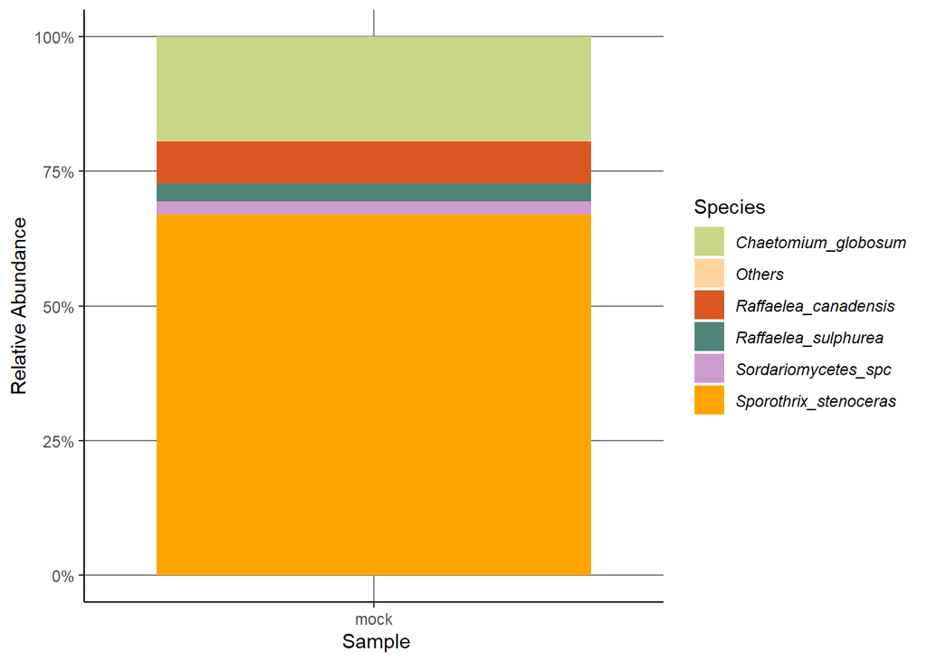

```r
Fungi_Species.mock_plot <-ggplot(Fungi_Species.mock, aes(x = Sample, y = Abundance, fill = Species)) +
  geom_bar(stat = "identity", color = NA, position="fill") +
  scale_fill_manual(values = Family_colors, name = "Species")

g1<-Fungi_Species.mock_plot +
  theme(plot.title = element_text(size = 20, face = "bold")) +
  theme(text = element_text(size=20, face = "bold"))+
  theme(axis.text.x=element_text(size = rel(0.5)))+
  theme(legend.title = element_text(size = 20), legend.text = element_text(size = 14))+
  theme_classic()+           #gets rid of background
  theme(panel.grid.major = element_line(colour = "grey50"))+
  labs(x=" Sample", y="Relative Abundance")+
  scale_y_continuous(labels=percent_format())+
  theme(legend.text = element_text(face = "italic"))

g1
```

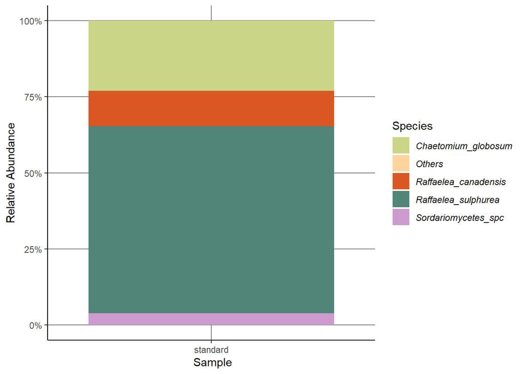

```r
Fungi_Species.std_plot <-ggplot(Fungi_Species.std, aes(x = Sample, y = Abundance, fill = Species)) +
  geom_bar(stat = "identity", color = NA, position="fill") +
  scale_fill_manual(values = Family_colors, name = "Species")

g2<-Fungi_Species.std_plot +
  theme(plot.title = element_text(size = 20, face = "bold")) +
  theme(text = element_text(size=20, face = "bold"))+
  theme(axis.text.x=element_text(size = rel(0.5)))+
  theme(legend.title = element_text(size = 20), legend.text = element_text(size = 14))+
  theme_classic()+           #gets rid of background
  theme(panel.grid.major = element_line(colour = "grey50"))+
  labs(x=" Sample", y="Relative Abundance")+
  scale_y_continuous(labels=percent_format())+
  theme(legend.text = element_text(face = "italic"))

g2
```

negative controls prae decontam

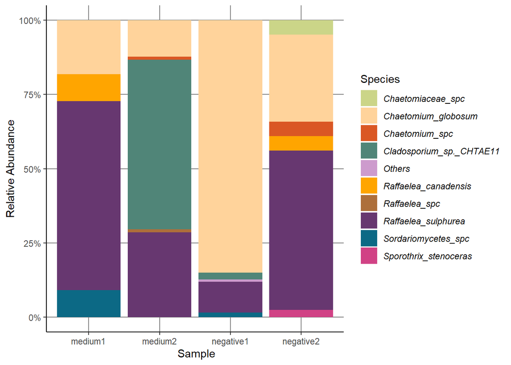

```r
Fungi_Species.neg_plot <-ggplot(Fungi_Species.neg, aes(x = Sample, y = Abundance, fill = Species)) +
  geom_bar(stat = "identity", color = NA, position="fill") +
  scale_fill_manual(values = Family_colors, name = "Species")

g3<-Fungi_Species.neg_plot +
  theme(plot.title = element_text(size = 20, face = "bold")) +
  theme(text = element_text(size=20, face = "bold"))+
  theme(axis.text.x=element_text(size = rel(0.5)))+
  theme(legend.title = element_text(size = 20), legend.text = element_text(size = 14))+
  theme_classic()+           #gets rid of background
  theme(panel.grid.major = element_line(colour = "grey50"))+
  labs(x=" Sample", y="Relative Abundance")+
  scale_y_continuous(labels=percent_format())+
  theme(legend.text = element_text(face = "italic"))

g3
```

## run decontam

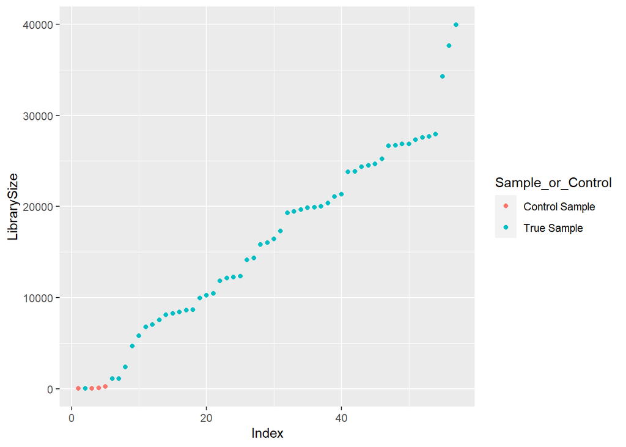

```r
library(decontam)
df <- as.data.frame(sample_data(dataset.LSU.ordi)) # Put sample_data into a ggplot-friendly data.frame
df$LibrarySize <- sample_sums(dataset.LSU.ordi)
df <- df[order(df$LibrarySize),]
df$Index <- seq(nrow(df))
ggplot(data=df, aes(x=Index, y=LibrarySize, color=Sample_or_Control)) + geom_point()
```

```r
sample_data(dataset.LSU.ordi)$is.neg <- sample_data(dataset.LSU.ordi)$Sample_or_Control == "Control Sample"
contamdf.prev <- isContaminant(dataset.LSU.ordi, method="prevalence", neg="is.neg")
table(contamdf.prev$contaminant)
```

```
##
## FALSE  TRUE
##   209     2
```

```r
ps.pa <- transform_sample_counts(dataset.LSU.ordi, function(abund) 1*(abund>0))
ps.pa.neg <- prune_samples(sample_data(ps.pa)$Sample_or_Control == "Control Sample", ps.pa)
ps.pa.pos <- prune_samples(sample_data(ps.pa)$Sample_or_Control == "True Sample", ps.pa)
```

Make data.frame of prevalence in positive and negative samples

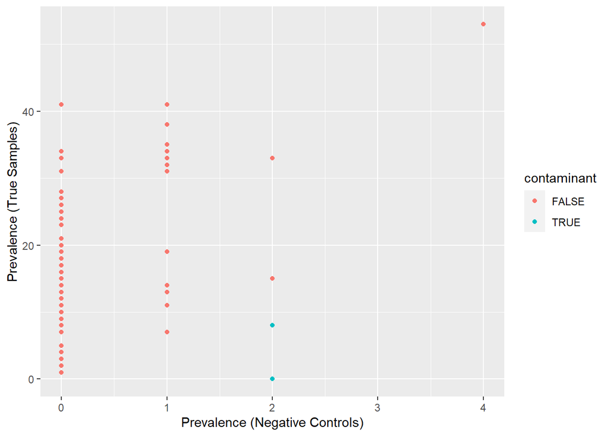

```r
df.pa <- data.frame(pa.pos=taxa_sums(ps.pa.pos), pa.neg=taxa_sums(ps.pa.neg),contaminant=contamdf.prev$contaminant)
ggplot(data=df.pa, aes(x=pa.neg, y=pa.pos, color=contaminant)) + geom_point() + xlab("Prevalence (Negative Controls)") + ylab("Prevalence (True Samples)")
```

```r
ps.noncontam_dataset.LSU.ordi <- prune_taxa(!contamdf.prev$contaminant, dataset.LSU.ordi)
ps.noncontam_dataset.LSU.ordi
```

```
## phyloseq-class experiment-level object
## otu_table()   OTU Table:         [ 209 taxa and 57 samples ]
## sample_data() Sample Data:       [ 57 samples by 17 sample variables ]
## tax_table()   Taxonomy Table:    [ 209 taxa by 8 taxonomic ranks ]
```

```r
smin <- min(sample_sums(ps.noncontam_dataset.LSU.ordi))
smean <- mean(sample_sums(ps.noncontam_dataset.LSU.ordi))
smax <- max(sample_sums(ps.noncontam_dataset.LSU.ordi))
cat("The minimum sample read count is:",smin) #11
```

```
## The minimum sample read count is: 11
```

```r
cat("The average sample read count is:",smean) #15670.75
```

```
## The average sample read count is: 15670.75
```

```r
cat("The maximum sample read count is:",smax) #39932
```

```
## The maximum sample read count is: 39932
```

#### create a list of all excluded contaminants

```r
contaminants <- subset(contamdf.prev, contaminant == "TRUE")
```

## check controls post decontam

prepare data for plotting

```r
mock2 <- subset_samples(ps.noncontam_dataset.LSU.ordi, Sample == "mock")
std2 <- subset_samples(ps.noncontam_dataset.LSU.ordi, Sample == "standard")

negs2 <- subset_samples(ps.noncontam_dataset.LSU.ordi, Treatment == "negative" | Treatment == "medium")

Fungi_Species.mock2 <- mock2 %>%
  tax_glom(taxrank = "Species") %>%
  transform_sample_counts(function(x) {x/sum(x)} ) %>%
  psmelt() %>%
  arrange(Species)

Fungi_Species.mock2$Species<-as.character(Fungi_Species.mock2$Species)
Fungi_Species.mock2$Species[Fungi_Species.mock2$Abundance<0.01]<-"Others"
Fungi_Species.mock2$Class<-as.character(Fungi_Species.mock2$Class)
Fungi_Species.mock2$Class[Fungi_Species.mock2$Abundance<0.01]<-"Others"

Fungi_Species.std2 <- std2 %>%
  tax_glom(taxrank = "Species") %>%
  transform_sample_counts(function(x) {x/sum(x)} ) %>%
  psmelt() %>%
  arrange(Species)

Fungi_Species.std2$Species<-as.character(Fungi_Species.std2$Species)
Fungi_Species.std2$Species[Fungi_Species.std2$Abundance<0.01]<-"Others"
Fungi_Species.std2$Class<-as.character(Fungi_Species.std2$Class)
Fungi_Species.std2$Class[Fungi_Species.std2$Abundance<0.01]<-"Others"

Fungi_Species.neg2 <- negs2 %>%
  tax_glom(taxrank = "Species") %>%
  transform_sample_counts(function(x) {x/sum(x)} ) %>%
  psmelt() %>%
  arrange(Species)

Fungi_Species.neg2$Species<-as.character(Fungi_Species.neg2$Species)
Fungi_Species.neg2$Species[Fungi_Species.neg2$Abundance<0.01]<-"Others"
Fungi_Species.neg2$Class<-as.character(Fungi_Species.neg2$Class)
Fungi_Species.neg2$Class[Fungi_Species.neg2$Abundance<0.01]<-"Others"
```

positive controls post decontam

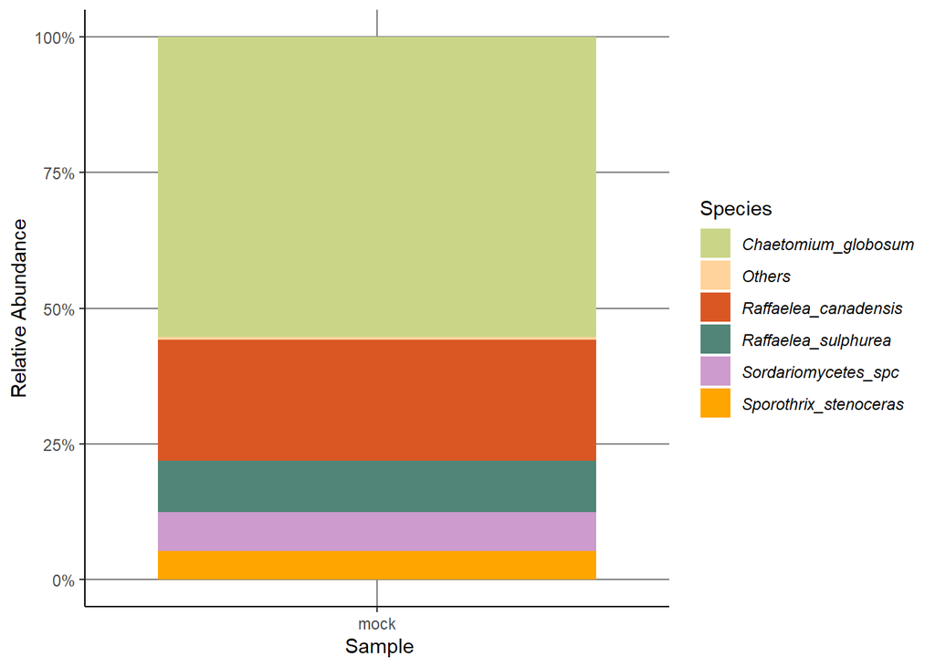

```r
Fungi_Species.mock2_plot <-ggplot(Fungi_Species.mock2, aes(x = Sample, y = Abundance, fill = Species)) +
  geom_bar(stat = "identity", color = NA, position="fill") +
  scale_fill_manual(values = Family_colors, name = "Species")

g4<-Fungi_Species.mock2_plot +
  theme(plot.title = element_text(size = 20, face = "bold")) +
  theme(text = element_text(size=20, face = "bold"))+
  theme(axis.text.x=element_text(size = rel(0.5)))+
  theme(legend.title = element_text(size = 20), legend.text = element_text(size = 14))+
  theme_classic()+           #gets rid of background
  theme(panel.grid.major = element_line(colour = "grey50"))+
  labs(x=" Sample", y="Relative Abundance")+
  scale_y_continuous(labels=percent_format())+
  theme(legend.text = element_text(face = "italic"))

g4
```

standard controls post decontam

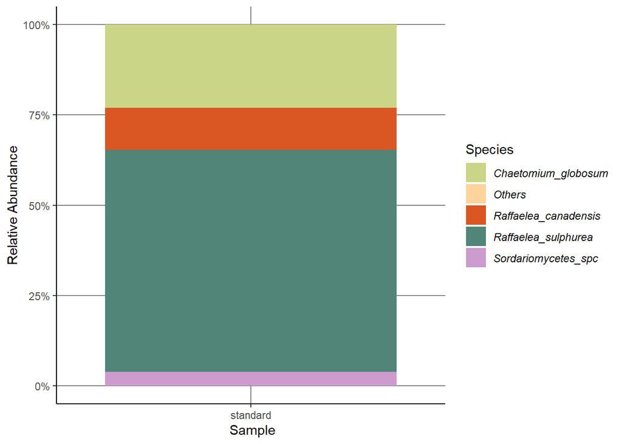

```r
Fungi_Species.std2_plot <-ggplot(Fungi_Species.std2, aes(x = Sample, y = Abundance, fill = Species)) +
  geom_bar(stat = "identity", color = NA, position="fill") +
  scale_fill_manual(values = Family_colors, name = "Species")

g5<-Fungi_Species.std2_plot +
  theme(plot.title = element_text(size = 20, face = "bold")) +
  theme(text = element_text(size=20, face = "bold"))+
  theme(axis.text.x=element_text(size = rel(0.5)))+
  theme(legend.title = element_text(size = 20), legend.text = element_text(size = 14))+
  theme_classic()+           #gets rid of background
  theme(panel.grid.major = element_line(colour = "grey50"))+
  labs(x=" Sample", y="Relative Abundance")+
  scale_y_continuous(labels=percent_format())+
  theme(legend.text = element_text(face = "italic"))

g5
```

negative controls post decontam

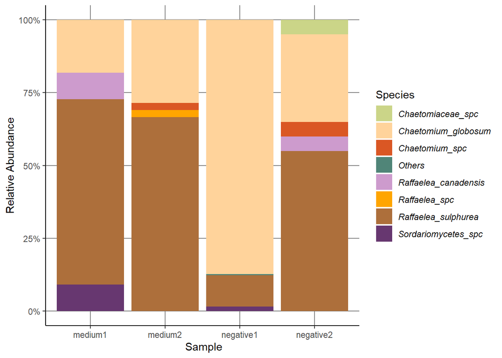

```r
Fungi_Species.neg2_plot <-ggplot(Fungi_Species.neg2, aes(x = Sample, y = Abundance, fill = Species)) +
  geom_bar(stat = "identity", color = NA, position="fill") +
  scale_fill_manual(values = Family_colors, name = "Species")

g6<-Fungi_Species.neg2_plot +
  theme(plot.title = element_text(size = 20, face = "bold")) +
  theme(text = element_text(size=20, face = "bold"))+
  theme(axis.text.x=element_text(size = rel(0.5)))+
  theme(legend.title = element_text(size = 20), legend.text = element_text(size = 14))+
  theme_classic()+           #gets rid of background
  theme(panel.grid.major = element_line(colour = "grey50"))+
  labs(x=" Sample", y="Relative Abundance")+
  scale_y_continuous(labels=percent_format())+
  theme(legend.text = element_text(face = "italic"))

g6
```

```r
fun.without.controls <- subset_samples(ps.noncontam_dataset.LSU.ordi, Treatment!="medium")
fun.without.controls2 <- subset_samples(fun.without.controls, Treatment!="negative")
fun.without.controls3 <- subset_samples(fun.without.controls2, Treatment!="mock")
fwc <- subset_samples(fun.without.controls3, Treatment!="standard")
```

get rid of no read taxa and unimportant metadata in dataset

```r
fwc <- prune_taxa(taxa_sums(fwc) > 0, fwc)

sample_data(fwc) <- sample_data(fwc)[,c("Sample","Nest","Linage","Treatment", "age_sampling_d.","Group")]
```

### now have a look at the 15 most abundant ZOTUS in our samples

```r
most.abundant<-subset_samples(fwc, Treatment=="control" | Treatment=="removal" | Treatment=="2nd-foundation")
```

```r
filtaxa <- names (sort(rowSums(otu_table(most.abundant)) ,decreasing=T))[1:15]
tax_table(fwc)[filtaxa]
```

```
## Taxonomy Table:     [15 taxa by 8 taxonomic ranks]:
##                                Domain  Phylum       Class
## LSUzotu1:Chaetomium_globosum   "Fungi" "Ascomycota" "Sordariomycetes"
## LSUzotu2:Raffaelea_sulphurea   "Fungi" "Ascomycota" "Sordariomycetes"
## LSUzotu3:Acremonium_biseptum   "Fungi" "Ascomycota" "Sordariomycetes"
## LSUzotu4:Raffaelea_canadensis  "Fungi" "Ascomycota" "Sordariomycetes"
## LSUzotu5:Raffaelea_canadensis  "Fungi" "Ascomycota" "Sordariomycetes"
## LSUzotu8:Penicillium_commune   "Fungi" "Ascomycota" "Eurotiomycetes"
## LSUzotu19:Chaetomium_globosum  "Fungi" "Ascomycota" "Sordariomycetes"
## LSUzotu23:Raffaelea_sulphurea  "Fungi" "Ascomycota" "Sordariomycetes"
## LSUzotu25:Raffaelea_sulphurea  "Fungi" "Ascomycota" "Sordariomycetes"
## LSUzotu7:Raffaelea_sulphurea   "Fungi" "Ascomycota" "Sordariomycetes"
## LSUzotu26:Chaetomium_spc       "Fungi" "Ascomycota" "Sordariomycetes"
## LSUzotu9:Raffaelea_spc         "Fungi" "Ascomycota" "Sordariomycetes"
## LSUzotu36:Raffaelea_sulphurea  "Fungi" "Ascomycota" "Sordariomycetes"
## LSUzotu11:Raffaelea_canadensis "Fungi" "Ascomycota" "Sordariomycetes"
## LSUzotu37:Raffaelea_canadensis "Fungi" "Ascomycota" "Sordariomycetes"
##                                Order             Family
## LSUzotu1:Chaetomium_globosum   "Sordariales"     "Chaetomiaceae"
## LSUzotu2:Raffaelea_sulphurea   "Ophiostomatales" "Ophiostomataceae"
## LSUzotu3:Acremonium_biseptum   "Hypocreales"     "Bionectriaceae"
## LSUzotu4:Raffaelea_canadensis  "Ophiostomatales" "Ophiostomataceae"
## LSUzotu5:Raffaelea_canadensis  "Ophiostomatales" "Ophiostomataceae"
## LSUzotu8:Penicillium_commune   "Eurotiales"      "Trichocomaceae"
## LSUzotu19:Chaetomium_globosum  "Sordariales"     "Chaetomiaceae"
## LSUzotu23:Raffaelea_sulphurea  "Ophiostomatales" "Ophiostomataceae"
## LSUzotu25:Raffaelea_sulphurea  "Ophiostomatales" "Ophiostomataceae"
## LSUzotu7:Raffaelea_sulphurea   "Ophiostomatales" "Ophiostomataceae"
## LSUzotu26:Chaetomium_spc       "Sordariales"     "Chaetomiaceae"
## LSUzotu9:Raffaelea_spc         "Ophiostomatales" "Ophiostomataceae"
## LSUzotu36:Raffaelea_sulphurea  "Ophiostomatales" "Ophiostomataceae"
## LSUzotu11:Raffaelea_canadensis "Ophiostomatales" "Ophiostomataceae"
## LSUzotu37:Raffaelea_canadensis "Ophiostomatales" "Ophiostomataceae"
##                                Genus         Species
## LSUzotu1:Chaetomium_globosum   "Chaetomium"  "Chaetomium_globosum"
## LSUzotu2:Raffaelea_sulphurea   "Raffaelea"   "Raffaelea_sulphurea"
## LSUzotu3:Acremonium_biseptum   "Acremonium"  "Acremonium_biseptum"
## LSUzotu4:Raffaelea_canadensis  "Raffaelea"   "Raffaelea_canadensis"
## LSUzotu5:Raffaelea_canadensis  "Raffaelea"   "Raffaelea_canadensis"
## LSUzotu8:Penicillium_commune   "Penicillium" "Penicillium_commune"
```

[output cut: 10 more lines]

```
## LSUzotu1:Chaetomium_globosum   "LSUzotu1:Chaetomium_globosum"
## LSUzotu2:Raffaelea_sulphurea   "LSUzotu2:Raffaelea_sulphurea"
## LSUzotu3:Acremonium_biseptum   "LSUzotu3:Acremonium_biseptum"
## LSUzotu4:Raffaelea_canadensis  "LSUzotu4:Raffaelea_canadensis"
## LSUzotu5:Raffaelea_canadensis  "LSUzotu5:Raffaelea_canadensis"
## LSUzotu8:Penicillium_commune   "LSUzotu8:Penicillium_commune"
## LSUzotu19:Chaetomium_globosum  "LSUzotu19:Chaetomium_globosum"
## LSUzotu23:Raffaelea_sulphurea  "LSUzotu23:Raffaelea_sulphurea"
## LSUzotu25:Raffaelea_sulphurea  "LSUzotu25:Raffaelea_sulphurea"
## LSUzotu7:Raffaelea_sulphurea   "LSUzotu7:Raffaelea_sulphurea"
## LSUzotu26:Chaetomium_spc       "LSUzotu26:Chaetomium_spc"
## LSUzotu9:Raffaelea_spc         "LSUzotu9:Raffaelea_spc"
## LSUzotu36:Raffaelea_sulphurea  "LSUzotu36:Raffaelea_sulphurea"
## LSUzotu11:Raffaelea_canadensis "LSUzotu11:Raffaelea_canadensis"
## LSUzotu37:Raffaelea_canadensis "LSUzotu37:Raffaelea_canadensis"
```

```r
round(otu_table(fwc)[filtaxa], digits = 4)
```

```
## OTU Table:          [15 taxa and 51 samples]
##                      taxa are rows
##                                B0-19a B0-19b B0-22a B0-22b B0-24 B0-27 B10-01
## LSUzotu1:Chaetomium_globosum      258  19888  19631  34239  7239  1340    170
## LSUzotu2:Raffaelea_sulphurea     7705      9     22      6 15410 10421  16220
## LSUzotu3:Acremonium_biseptum        0      0      0      0     0     0      0
## LSUzotu4:Raffaelea_canadensis     251      1     11   2284  2764  3024     13
## LSUzotu5:Raffaelea_canadensis       0     45      4      0     1     1   3221
## LSUzotu8:Penicillium_commune        0      0      0      0     0     0      0
## LSUzotu19:Chaetomium_globosum       0      0      0      2    99    20      3
## LSUzotu23:Raffaelea_sulphurea       0      0      0      0   172    30      6
## LSUzotu25:Raffaelea_sulphurea       0      0      0      0    97    15      4
## LSUzotu7:Raffaelea_sulphurea      386      0      0      0   548   380    109
## LSUzotu26:Chaetomium_spc            0      0      0      0    86    22      2
## LSUzotu9:Raffaelea_spc              2      0      0      0   170   192      2
## LSUzotu36:Raffaelea_sulphurea       0      0      0      0    63    19      2
## LSUzotu11:Raffaelea_canadensis      0      0      0      0     0     0    535
## LSUzotu37:Raffaelea_canadensis      3      0      0      0   123   187      0
##                                B10-06 B10-09a B10-09b B10-18 B10-24 B10-25a
## LSUzotu1:Chaetomium_globosum    11309   18613   35695   2094   1159    6733
## LSUzotu2:Raffaelea_sulphurea    13569    5195       7   3573   7565   13414
## LSUzotu3:Acremonium_biseptum        0       0       0      0      0       0
## LSUzotu4:Raffaelea_canadensis       0       1       0      2      0       2
## LSUzotu5:Raffaelea_canadensis     161       7    2030    540    885     861
## LSUzotu8:Penicillium_commune        0       0       0      0      0       0
## LSUzotu19:Chaetomium_globosum     192     491       0     48     24     452
## LSUzotu23:Raffaelea_sulphurea     312     673       0     39     35     255
## LSUzotu25:Raffaelea_sulphurea     179     213       0     43     19     305
## LSUzotu7:Raffaelea_sulphurea      125     115       0     40     64     116
## LSUzotu26:Chaetomium_spc          165     184       0     48     25     287
## LSUzotu9:Raffaelea_spc              4       0       0      1      1      14
## LSUzotu36:Raffaelea_sulphurea     139     150       0     41     20     267
## LSUzotu11:Raffaelea_canadensis     11       0       0     38    102     132
## LSUzotu37:Raffaelea_canadensis      0       0       1      0      0       0
##                                B10-25b B10-26a B15-01a B15-01b B15-06 B15-07a
## LSUzotu1:Chaetomium_globosum        95    4421      33   20163      4   15782
## LSUzotu2:Raffaelea_sulphurea      7353   18965    9796    2454   1589    2382
## LSUzotu3:Acremonium_biseptum         0       0     102       0     96      29
## LSUzotu4:Raffaelea_canadensis        0       1    1260     257    524     178
## LSUzotu5:Raffaelea_canadensis     3875     413       0       0      0       0
```

[output cut: 91 more lines]

```
## LSUzotu1:Chaetomium_globosum    2230   4660
## LSUzotu2:Raffaelea_sulphurea    3522      5
## LSUzotu3:Acremonium_biseptum       0      2
## LSUzotu4:Raffaelea_canadensis      0     14
## LSUzotu5:Raffaelea_canadensis      0      0
## LSUzotu8:Penicillium_commune       0      0
## LSUzotu19:Chaetomium_globosum     11      0
## LSUzotu23:Raffaelea_sulphurea      3      2
## LSUzotu25:Raffaelea_sulphurea      5      0
## LSUzotu7:Raffaelea_sulphurea      23      0
## LSUzotu26:Chaetomium_spc           5      0
## LSUzotu9:Raffaelea_spc             0      1
## LSUzotu36:Raffaelea_sulphurea      5      0
## LSUzotu11:Raffaelea_canadensis     0      0
## LSUzotu37:Raffaelea_canadensis     0      0
```

#### plot rel. abundance of present dataset to check abundances in sampels

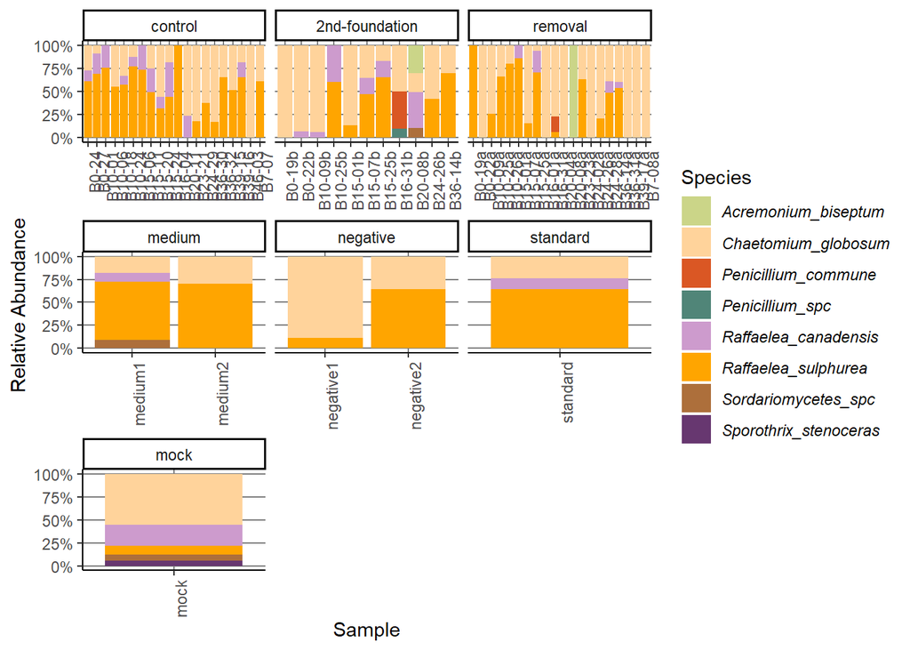

```r
Fungi_Species.all. <- ps.noncontam_dataset.LSU.ordi %>%
  tax_glom(taxrank = "Species") %>%
  transform_sample_counts(function(x) {x/sum(x)} ) %>%
  psmelt() %>%
  filter(Abundance > 0.05) %>%
  arrange(Species)

Fungi_Species.all.$Treatment <- factor(Fungi_Species.all.$Treatment, levels = c("control", "2nd-foundation", "removal", "medium", "negative", "standard", "mock"))

Fungi_Species_plot <-ggplot(Fungi_Species.all., aes(x = Sample, y = Abundance, fill = Species)) +
  geom_bar(stat = "identity", position="fill") +
  scale_fill_manual(values = Family_colors, name = "Species")

Fungi_Species_plot +
  facet_wrap("Treatment", scales = "free_x",  drop = TRUE)+
  theme(plot.title = element_text(size = 16, face = "bold")) +
  theme(text = element_text(size=16, face = "bold"))+
  theme(legend.title = element_text(size = 20), legend.text = element_text(size = 14))+
  theme_classic()+      theme(panel.grid.major = element_line(colour = "grey50"))+
  labs(x="Sample", y="Relative Abundance")+
  scale_y_continuous(labels=percent_format())+
  theme(axis.text.x=element_text(angle = 90, hjust = 1, size = rel(1)))+
  theme(legend.text = element_text(face = "italic"))
```

extract general information on data

```r
microbiome::summarize_phyloseq(fwc)
```

```
## Compositional = NO2
```

```
## 1] Min. number of reads = 10872] Max. number of reads = 399323] Total number of reads = 8845454] Average number of reads = 17344.01960784315] Median number of reads = 172797] Sparsity = 0.8222675208697346] Any OTU sum to 1 or less? YES8] Number of singletons = 49] Percent of OTUs that are singlet…
##         (i.e. exactly one read detected across all samples)1.9801980198019810] Number of sample variables are: 6SampleNestLinageTreatmentage_sampling_d.Group2
```

```
## [[1]]
## [1] "1] Min. number of reads = 1087"
##
## [[2]]
## [1] "2] Max. number of reads = 39932"
##
## [[3]]
## [1] "3] Total number of reads = 884545"
##
## [[4]]
## [1] "4] Average number of reads = 17344.0196078431"
##
## [[5]]
## [1] "5] Median number of reads = 17279"
##
## [[6]]
## [1] "7] Sparsity = 0.822267520869734"
##
## [[7]]
## [1] "6] Any OTU sum to 1 or less? YES"
##
## [[8]]
## [1] "8] Number of singletons = 4"
##
## [[9]]
## [1] "9] Percent of OTUs that are singletons \n        (i.e. exactly one read detected across all samples)1.98019801980198"
##
## [[10]]
## [1] "10] Number of sample variables are: 6"
##
## [[11]]
## [1] "Sample"          "Nest"            "Linage"          "Treatment"
## [5] "age_sampling_d." "Group"
```

```r
replicates <- subset.data.frame(sample_data(fwc))
table(replicates$Treatment)
```

```
##
## 2nd-foundation        control        removal
##             11             20             20
```

```r
sample_data(fwc)$ColSums <- colSums(otu_table(fwc))
```

# **Analysis**

## Rarefaction curves

1. all samples with controls
2. all samples with controls after decontam
3. all samples without controls

Rarefaction is used to simulate even number of reads per sample.

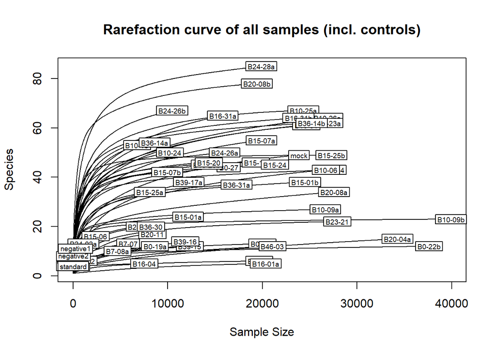

```r
rarecurve(t(otu_table(dataset.LSU.ordi)), cex=0.6, step = 20, main = "Rarefaction curve of all samples (incl. controls)")
```

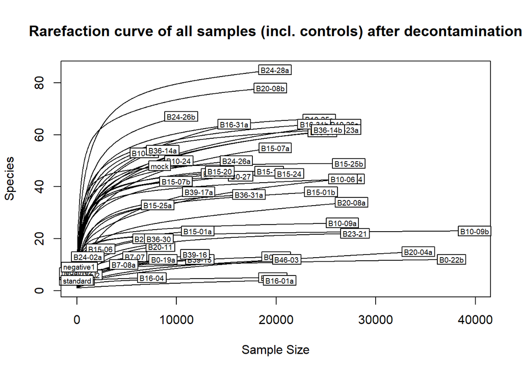

```r
rarecurve(t(otu_table(ps.noncontam_dataset.LSU.ordi)), cex=0.6, step = 20, main = "Rarefaction curve of all samples (incl. controls) after decontamination")
```

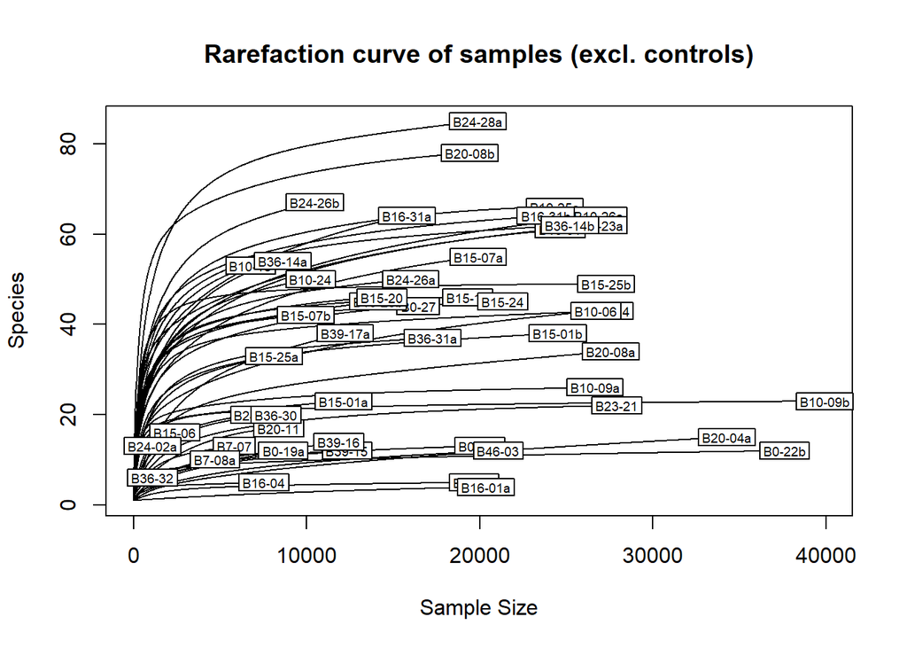

```r
rarecurve(t(otu_table(fwc)), cex=0.6, step = 20, main = "Rarefaction curve of samples (excl. controls)")
```

### rarefy to 2000 reads

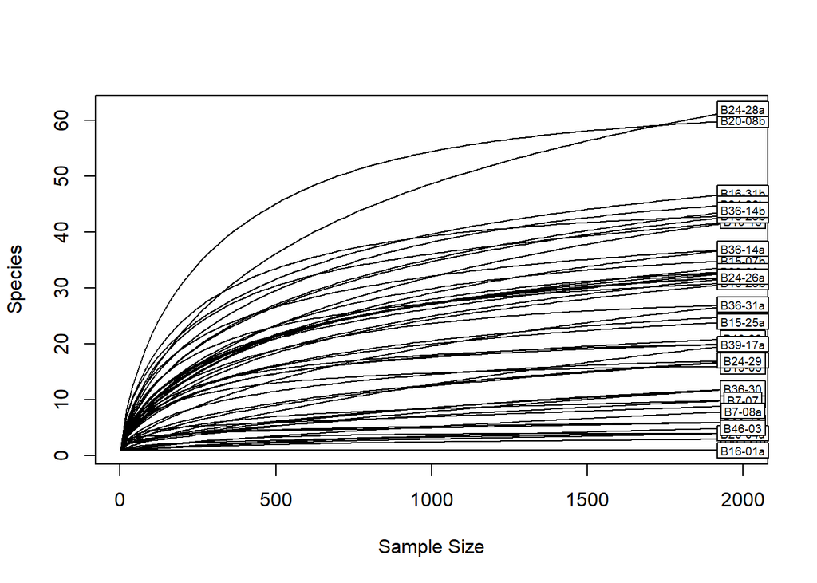

```r
ps2 <-fwc
set.seed(1)
ps2 <- rarefy_even_depth(ps2,sample.size=2000, replace=FALSE, rngseed = 1)
rarecurve(t(otu_table(ps2)), cex=0.6, step = 20)
```

```r
replicates3 <- subset.data.frame(sample_data(ps2))
table(replicates3$Treatment)
```

```
##
## 2nd-foundation        control        removal
##             11             19             19
```

### subset data to two comparison groups

```r
#control vs. removal
CR <- subset_samples(fwc, Treatment!="2nd-foundation")
CRrf <- subset_samples(ps2, Treatment!="2nd-foundation")

#removal vs. 2^nd^ attempt
R2nd <- subset_samples(fwc, Treatment!="control")
R2ndrf <- subset_samples(ps2, Treatment!="control")
```

## **Alpha diversity**

### **Diversity plots**

This returns a table with selected diversity indicators (Shannon diversity & Observed richness).

```r
tabCR <- microbiome::alpha(CRrf, index = c("diversity_shannon","observed"))

tabR2nd <- microbiome::alpha(R2ndrf, index = c("diversity_shannon","observed"))
```

#### Prepare data for vizualisation

Now, get the metadata (sample_data) from the phyloseq object

```r
ps1.meta.CR <- meta(CRrf)

ps1.meta.R2nd <- meta(R2ndrf)
```

Add the diversity table to metadata

```r
ps1.meta.CR$Shannon <- tabCR$diversity_shannon
ps1.meta.CR$Observed <- tabCR$observed

ps1.meta.R2nd$Shannon <- tabR2nd$diversity_shannon
ps1.meta.R2nd$Observed <- tabR2nd$observed
```

#### plot

control vs. removal (rarefied, 2000 reads)

```r
ps1.meta.CR$Treatment <- as.factor(ps1.meta.CR$Treatment)
ps1.meta.CR$Treatment <- factor(ps1.meta.CR$Treatment, levels = c("control", "removal"))

#Shannon diversity index
(a <- summaryBy(Shannon ~ Treatment, ps1.meta.CR, FUN = c(mean, sd)))
```

```
##   Treatment Shannon.mean Shannon.sd
## 1   control    0.9571066  0.4540992
## 2   removal    0.7803962  0.5793697
```

```r
p1 <- ggplot(ps1.meta.CR, aes(x = Treatment, y = Shannon))
shan_fun <- p1 + geom_jitter(position = position_jitter(w=0.2, h=0.1))+
    geom_pointrange(data = a, mapping = aes(x = Treatment, y = Shannon.mean, ymin = Shannon.mean-Shannon.sd, ymax = Shannon.mean + Shannon.sd), size = .9, color = "brown4")+
    theme_bw()+
    ylim(NA, 1.95)+
    labs(x = "Treatment group", y = "Shannon Diversity Index")+
  theme(axis.title = element_text(size = 18, face = "bold"), axis.text = element_text(size = 16))

#Observed richness
(b <- summaryBy(Observed ~ Treatment, ps1.meta.CR, FUN = c(mean, sd)))
```

```
##   Treatment Observed.mean Observed.sd
## 1   control      20.68421    12.79346
## 2   removal      24.36842    15.64612
```

```r
p2 <- ggplot(ps1.meta.CR, aes(x = Treatment, y = Observed))
obs_fun <- p2 + geom_jitter(position = position_jitter(w=0.2, h=0.1))+
    geom_pointrange(data = b, mapping = aes(x = Treatment, y = Observed.mean, ymin = Observed.mean-Observed.sd, ymax = Observed.mean + Observed.sd), size = .9, color = "brown4")+
    theme_bw()+
    ylim(NA, 70)
    labs(x = "Treatment group", y = "Observed richness")+
  theme(axis.title = element_text(size = 18, face = "bold"), axis.text = element_text(size = 16))
```

removal vs. 2<sup>nd</sup> attempt (rarefied, 2000 reads)

```r
ps1.meta.R2nd$Treatment <- as.factor(ps1.meta.R2nd$Treatment)
ps1.meta.R2nd$Treatment <- factor(ps1.meta.R2nd$Treatment, levels = c("removal", "2nd-foundation"), labels = c("removal", "2nd-attempt"))

#Shannon diversity index
(c <- summaryBy(Shannon ~ Treatment, ps1.meta.R2nd, FUN = c(mean, sd)))
```

```
##     Treatment Shannon.mean Shannon.sd
## 1     removal    0.7803962  0.5793697
## 2 2nd-attempt    1.2684611  0.7431823
```

```r
p3 <- ggplot(ps1.meta.R2nd, aes(x = Treatment, y = Shannon))
shan_fun2 <- p3 + geom_jitter(position = position_jitter(w=0.2, h=0.1))+
    geom_pointrange(data = c, mapping = aes(x = Treatment, y = Shannon.mean, ymin = Shannon.mean-Shannon.sd, ymax = Shannon.mean + Shannon.sd), size = .9, color = "brown4")+
    theme_bw()+
    ylim(NA, 2.7)+
    labs(x = "Treatment group", y = "Shannon Diversity Index")+
  theme(axis.title = element_text(size = 18, face = "bold"), axis.text = element_text(size = 16))

#Observed richness
(d <- summaryBy(Observed ~ Treatment, ps1.meta.R2nd, FUN = c(mean, sd)))
```

```
##     Treatment Observed.mean Observed.sd
## 1     removal      24.36842    15.64612
## 2 2nd-attempt      32.81818    17.28478
```

```r
p4 <- ggplot(ps1.meta.R2nd, aes(x = Treatment, y = Observed))
obs_fun2 <- p4 + geom_jitter(position = position_jitter(w=0.2, h=0.1))+
    geom_pointrange(data = d, mapping = aes(x = Treatment, y = Observed.mean, ymin = Observed.mean-Observed.sd, ymax = Observed.mean + Observed.sd), size = .9, color = "brown4")+
    theme_bw()+
    ylim(NA, 70)+
    labs(x = "Treatment group", y = "Observed richness")+
  theme(axis.title = element_text(size = 18, face = "bold"), axis.text = element_text(size = 16))
```

add statistical data output to plot

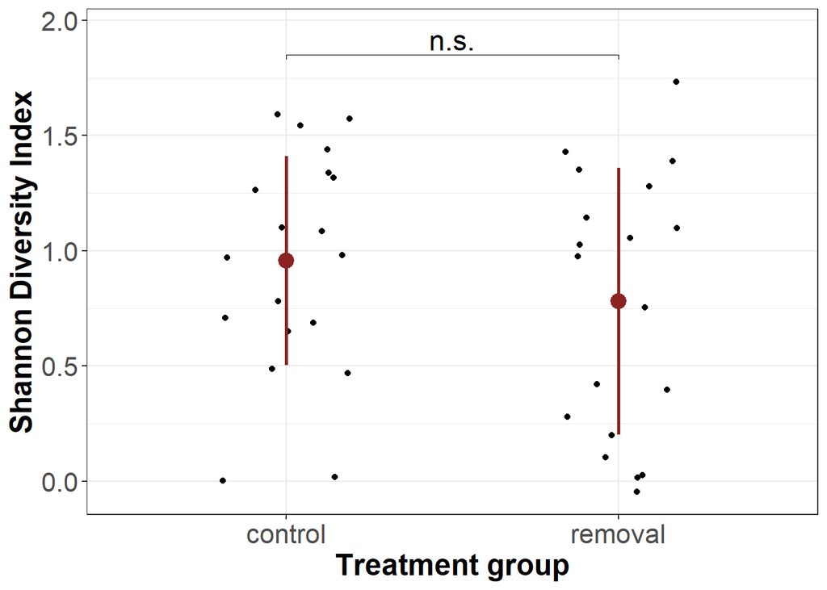

```r
shan_fun <- shan_fun + font("axis.title", size = 18)+
        font("xylab", size = 18)+
        geom_bracket(
            xmin = "control", xmax = "removal", y.position = 1.85, label = "n.s.", label.size = 6,tip.length = 0.01)

shan_fun
```

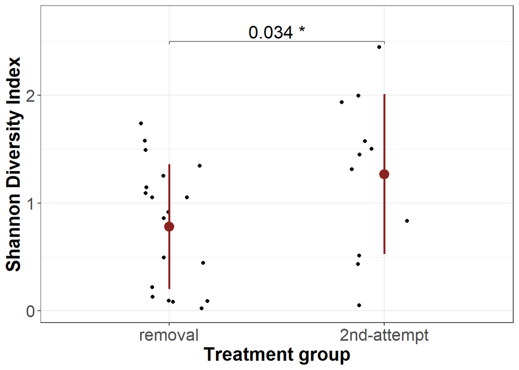

```r
shan_fun2 <- shan_fun2 + font("axis.title", size = 18)+
        font("xylab", size = 18)+
        geom_bracket(
            xmin = "removal", xmax = "2nd-attempt", y.position = 2.5, label = "0.034 *", label.size = 6,tip.length = 0.01)

shan_fun2
```

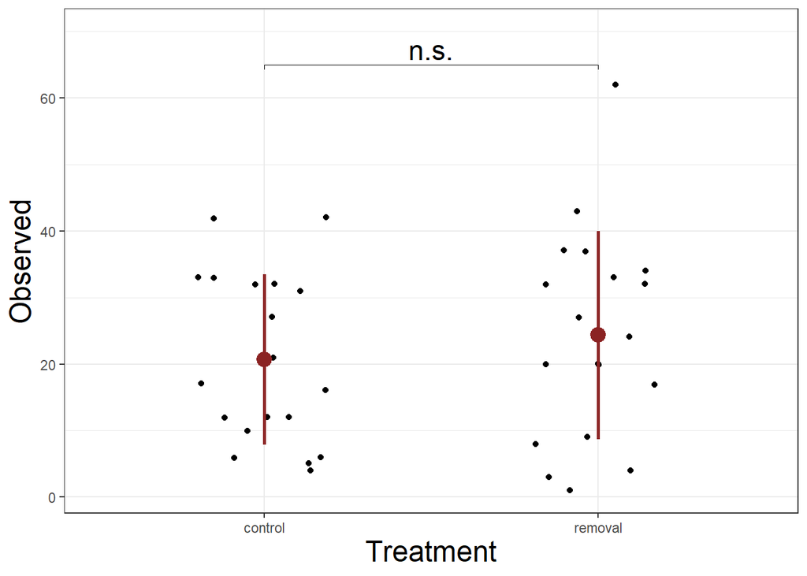

```r
obs_fun <- obs_fun + font("axis.title", size = 18)+
        font("xylab", size = 18)+
        geom_bracket(
            xmin = "control", xmax = "removal", y.position = 65, label = "n.s.", label.size = 6,tip.length = 0.01)

obs_fun
```

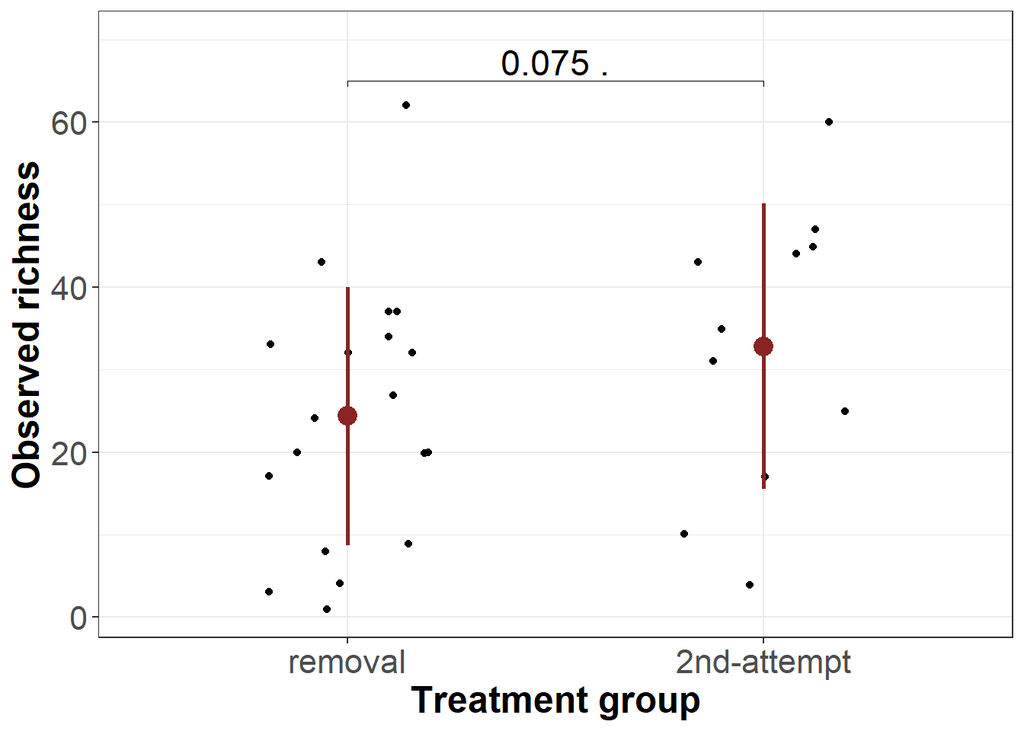

```r
obs_fun2 <- obs_fun2 + font("axis.title", size = 18)+
        font("xylab", size = 18)+
        geom_bracket(
            xmin = "removal", xmax = "2nd-attempt", y.position = 65, label = "0.075 .", label.size = 6,tip.length = 0.01)

obs_fun2
```

### **Statistics**

Testing differences in alpha diversity

create dataframe for analysis

```r
#control vs. removal
dCR <- meta(CRrf)
shannon <- diversity(CRrf, "shannon")
dCR$shannon <- shannon$shannon
observed <- alpha(CRrf, index = "observed", zeroes = TRUE)
dCR$observed <- observed$observed

#removal vs. 2^nd^ attempt
dR2nd <- meta(R2ndrf)
shannon <- diversity(R2ndrf, "shannon")
dR2nd$shannon <- shannon$shannon
observed <- alpha(R2ndrf, index = "observed", zeroes = TRUE)
dR2nd$observed <- observed$observed
```

#### **Shannon diversity**

test distribution

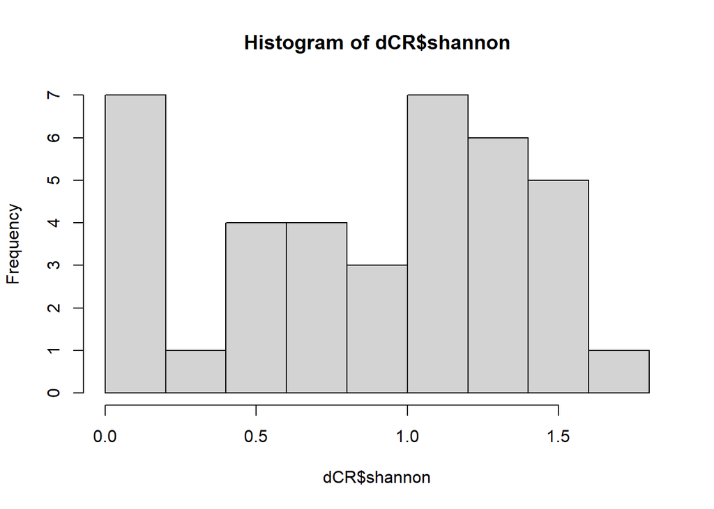

```r
hist(dCR$shannon)
```

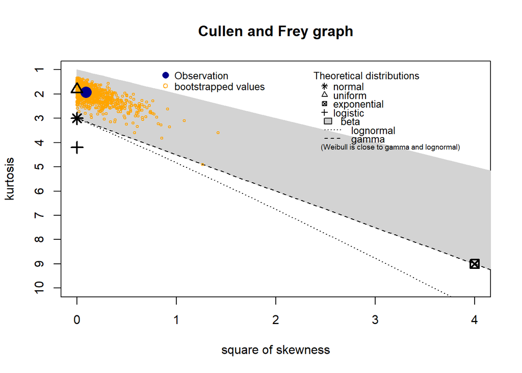

```
## summary statistics
## ------
## min:  0   max:  1.774394
## median:  0.9793887
## mean:  0.8687514
## estimated sd:  0.5211839
## estimated skewness:  -0.3021322
## estimated kurtosis:  1.921262
```

```r
descdist(dCR$shannon, boot = 1000)
```

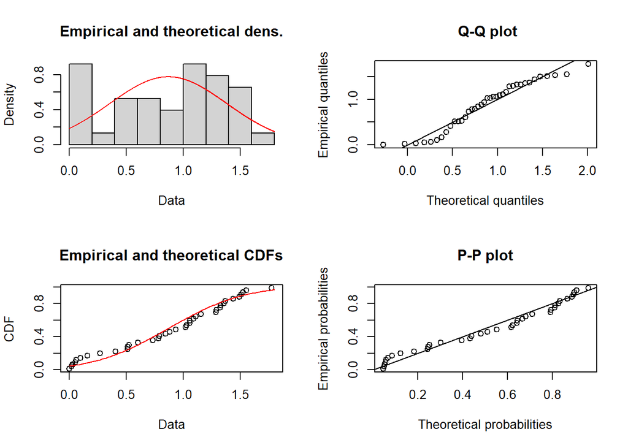

```r
fit.norm <- fitdist(dCR$shannon, distr = "norm", method = "mme") # looks good
plot(fit.norm)
```

test with subset 1

```r
dCR$Treatment <- as.factor(dCR$Treatment)
dCR <- within(dCR, Treatment <- relevel(Treatment, ref = "control"))

shan1 <- glm(shannon ~ Treatment + Linage, data = dCR)
Anova(shan1, type = "II")
```

```
## Analysis of Deviance Table (Type II tests)
##
## Response: shannon
##           LR Chisq Df Pr(>Chisq)
## Treatment   1.2779  1    0.25830
## Linage     22.5454 10    0.01255 *
## ---
## Signif. codes:  0 '***' 0.001 '**' 0.01 '*' 0.05 '.' 0.1 ' ' 1
```

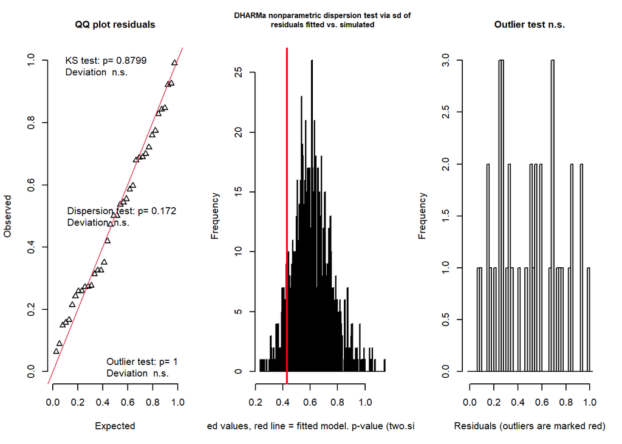

```
## $uniformity
##
##  One-sample Kolmogorov-Smirnov test
##
## data:  simulationOutput$scaledResiduals
## D = 0.095368, p-value = 0.8799
## alternative hypothesis: two-sided
##
##
## $dispersion
##
##  DHARMa nonparametric dispersion test via sd of residuals fitted vs.
##  simulated
##
## data:  simulationOutput
## dispersion = 0.70198, p-value = 0.172
## alternative hypothesis: two.sided
##
##
## $outliers
##
##  DHARMa outlier test based on exact binomial test with approximate
##  expectations
##
## data:  simulationOutput
## outliers at both margin(s) = 0, observations = 38, p-value = 1
## alternative hypothesis: true probability of success is not equal to 0.001998002
## 95 percent confidence interval:
##  0.00000000 0.09251276
## sample estimates:
## frequency of outliers (expected: 0.001998001998002 )
##                                                    0
```

```
## $uniformity
##
##  One-sample Kolmogorov-Smirnov test
##
## data:  simulationOutput$scaledResiduals
## D = 0.095368, p-value = 0.8799
## alternative hypothesis: two-sided
##
##
## $dispersion
##
##  DHARMa nonparametric dispersion test via sd of residuals fitted vs.
##  simulated
##
## data:  simulationOutput
## dispersion = 0.70198, p-value = 0.172
## alternative hypothesis: two.sided
##
##
## $outliers
##
##  DHARMa outlier test based on exact binomial test with approximate
##  expectations
##
## data:  simulationOutput
## outliers at both margin(s) = 0, observations = 38, p-value = 1
## alternative hypothesis: true probability of success is not equal to 0.001998002
## 95 percent confidence interval:
##  0.00000000 0.09251276
## sample estimates:
## frequency of outliers (expected: 0.001998001998002 )
##                                                    0
```

```r
res_shan1 <- simulateResiduals(shan1, n = 1000)
testResiduals(res_shan1)
```

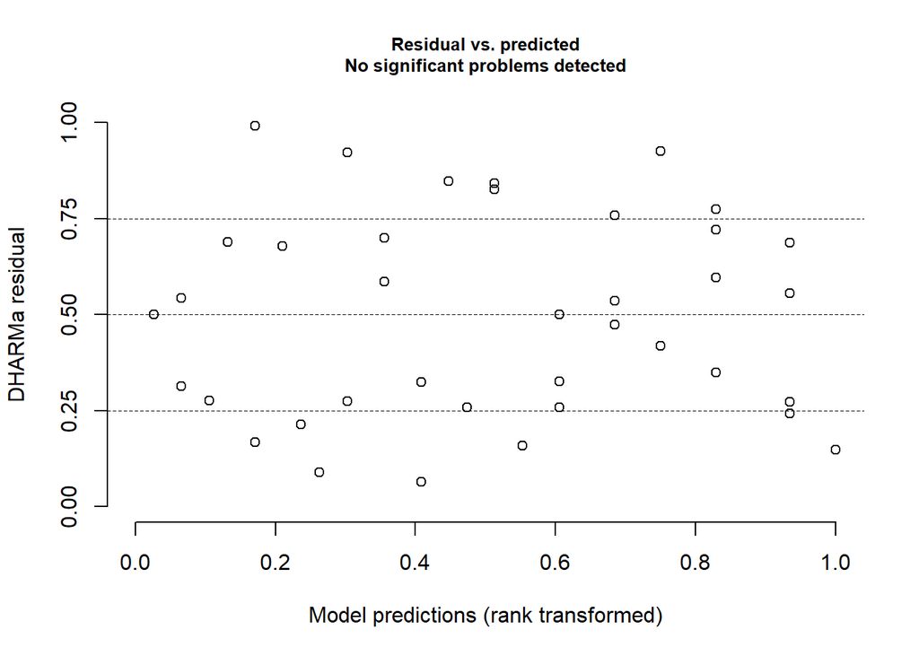

```r
plotResiduals(res_shan1)
```

–> strong Lineage effect in B24, Lineage with high abundant Erwinia, Ochrobactrum and Microbacterium inside

test with subset 2

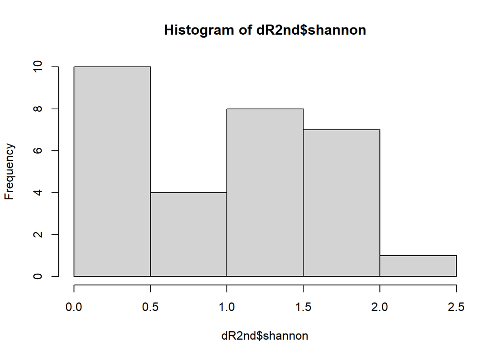

```r
hist(dR2nd$shannon)
```

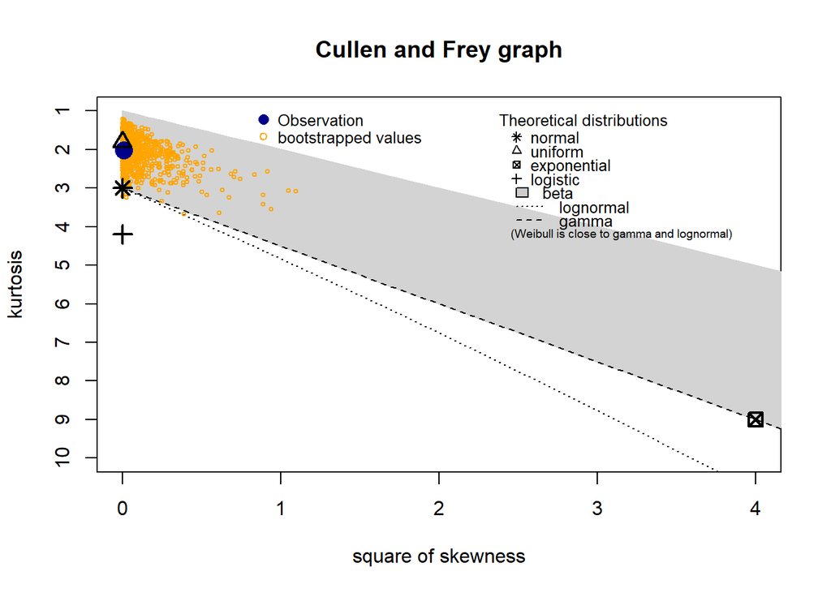

```
## summary statistics
## ------
## min:  0   max:  2.372804
## median:  1.044649
## mean:  0.9593534
## estimated sd:  0.675297
## estimated skewness:  0.1004296
## estimated kurtosis:  2.019042
```

```r
descdist(dR2nd$shannon, boot = 1000)
```

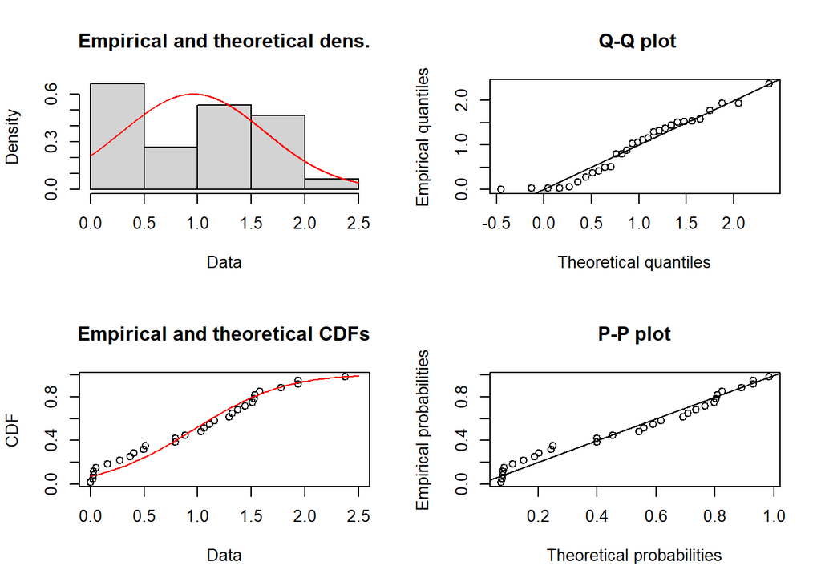

```r
fit.norm <- fitdist(dR2nd$shannon, distr = "norm", method = "mme") # looks good
plot(fit.norm)
```

```r
shan <- glm(shannon ~ Treatment + Linage, data = dR2nd)
Anova(shan, type = "II")
```

```
## Analysis of Deviance Table (Type II tests)
##
## Response: shannon
##           LR Chisq Df Pr(>Chisq)
## Treatment   4.5059  1    0.03378 *
## Linage     14.1368  9    0.11754
## ---
## Signif. codes:  0 '***' 0.001 '**' 0.01 '*' 0.05 '.' 0.1 ' ' 1
```

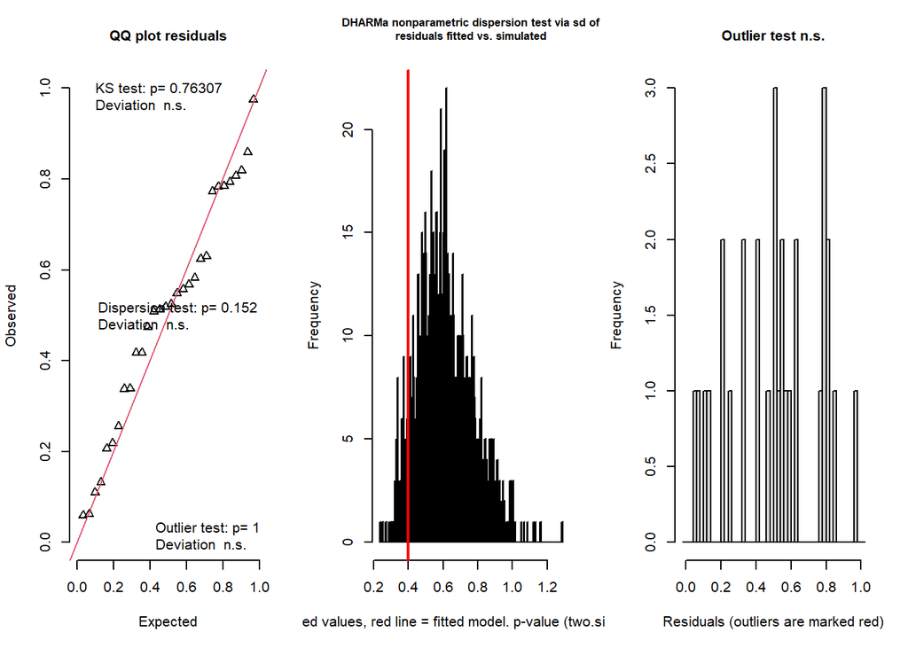

```
## $uniformity
##
##  One-sample Kolmogorov-Smirnov test
##
## data:  simulationOutput$scaledResiduals
## D = 0.117, p-value = 0.7631
## alternative hypothesis: two-sided
##
##
## $dispersion
##
##  DHARMa nonparametric dispersion test via sd of residuals fitted vs.
##  simulated
##
## data:  simulationOutput
## dispersion = 0.65369, p-value = 0.152
## alternative hypothesis: two.sided
##
##
## $outliers
##
##  DHARMa outlier test based on exact binomial test with approximate
##  expectations
##
## data:  simulationOutput
## outliers at both margin(s) = 0, observations = 30, p-value = 1
## alternative hypothesis: true probability of success is not equal to 0.001998002
## 95 percent confidence interval:
##  0.0000000 0.1157033
## sample estimates:
## frequency of outliers (expected: 0.001998001998002 )
##                                                    0
```

```
## $uniformity
##
##  One-sample Kolmogorov-Smirnov test
##
## data:  simulationOutput$scaledResiduals
## D = 0.117, p-value = 0.7631
## alternative hypothesis: two-sided
##
##
## $dispersion
##
##  DHARMa nonparametric dispersion test via sd of residuals fitted vs.
##  simulated
##
## data:  simulationOutput
## dispersion = 0.65369, p-value = 0.152
## alternative hypothesis: two.sided
##
##
## $outliers
##
##  DHARMa outlier test based on exact binomial test with approximate
##  expectations
##
## data:  simulationOutput
## outliers at both margin(s) = 0, observations = 30, p-value = 1
## alternative hypothesis: true probability of success is not equal to 0.001998002
## 95 percent confidence interval:
##  0.0000000 0.1157033
## sample estimates:
## frequency of outliers (expected: 0.001998001998002 )
##                                                    0
```

```r
res_shan <- simulateResiduals(shan, n = 1000)
testResiduals(res_shan)
```

#### **Observed richness**

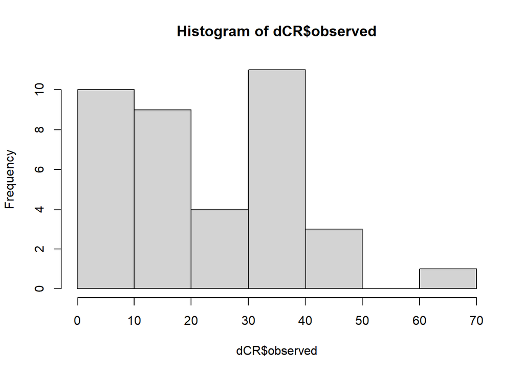

```r
hist(dCR$observed)
```

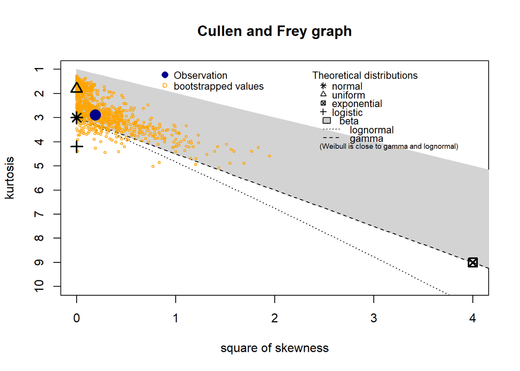

```
## summary statistics
## ------
## min:  1   max:  62
## median:  20.5
## mean:  22.52632
## estimated sd:  14.21977
## estimated skewness:  0.4350977
## estimated kurtosis:  2.891807
```

```r
descdist(dCR$observed, boot = 1000)
```

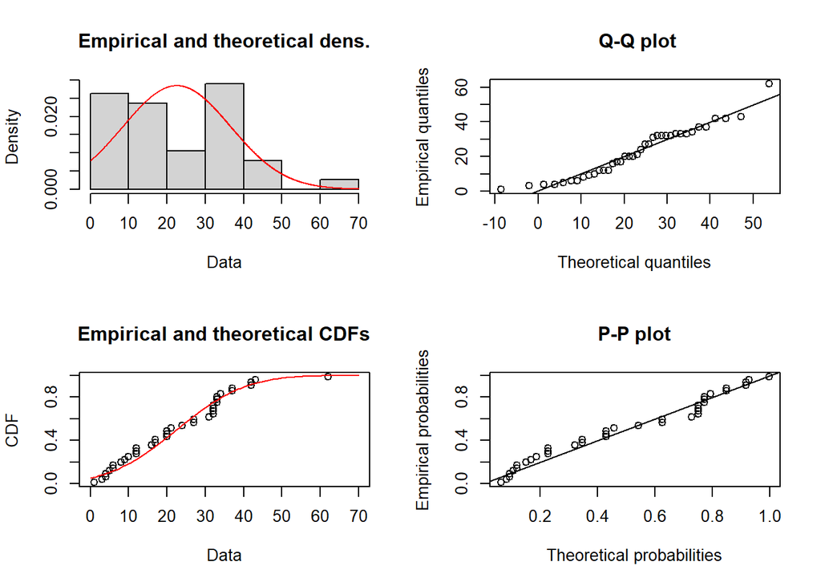

```r
fit.norm <- fitdist(dCR$observed, distr = "norm", method = "mme") # looks good
plot(fit.norm)
```

run model

```r
dCR$Treatment <- as.factor(dCR$Treatment)
dCR <- within(dCR, Treatment <- relevel(Treatment, ref = "control"))

ob1 <- glm(observed ~ Treatment + Linage, data = dCR)
Anova(ob1, type = "II")
```

```
## Analysis of Deviance Table (Type II tests)
##
## Response: observed
##           LR Chisq Df Pr(>Chisq)
## Treatment   0.6393  1    0.42395
## Linage     21.9446 10    0.01539 *
## ---
## Signif. codes:  0 '***' 0.001 '**' 0.01 '*' 0.05 '.' 0.1 ' ' 1
```

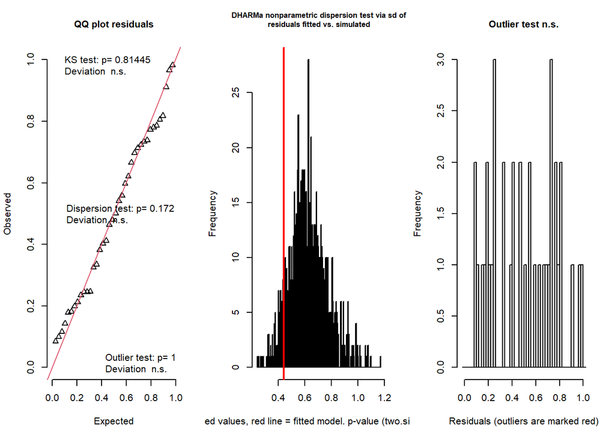

```
## $uniformity
##
##  One-sample Kolmogorov-Smirnov test
##
## data:  simulationOutput$scaledResiduals
## D = 0.10305, p-value = 0.8144
## alternative hypothesis: two-sided
##
##
## $dispersion
##
##  DHARMa nonparametric dispersion test via sd of residuals fitted vs.
##  simulated
##
## data:  simulationOutput
## dispersion = 0.70198, p-value = 0.172
## alternative hypothesis: two.sided
##
##
## $outliers
##
##  DHARMa outlier test based on exact binomial test with approximate
##  expectations
##
## data:  simulationOutput
## outliers at both margin(s) = 0, observations = 38, p-value = 1
## alternative hypothesis: true probability of success is not equal to 0.001998002
## 95 percent confidence interval:
##  0.00000000 0.09251276
## sample estimates:
## frequency of outliers (expected: 0.001998001998002 )
##                                                    0
```

```
## $uniformity
##
##  One-sample Kolmogorov-Smirnov test
##
## data:  simulationOutput$scaledResiduals
## D = 0.10305, p-value = 0.8144
## alternative hypothesis: two-sided
##
##
## $dispersion
##
##  DHARMa nonparametric dispersion test via sd of residuals fitted vs.
##  simulated
##
## data:  simulationOutput
## dispersion = 0.70198, p-value = 0.172
## alternative hypothesis: two.sided
##
##
## $outliers
##
##  DHARMa outlier test based on exact binomial test with approximate
##  expectations
##
## data:  simulationOutput
## outliers at both margin(s) = 0, observations = 38, p-value = 1
## alternative hypothesis: true probability of success is not equal to 0.001998002
## 95 percent confidence interval:
##  0.00000000 0.09251276
## sample estimates:
## frequency of outliers (expected: 0.001998001998002 )
##                                                    0
```

```r
res_ob1 <- simulateResiduals(ob1, n = 1000)
testResiduals(res_ob1)
```

choose normal distribution